# PD_DDM Trait Structure Analysis

Timothy Allen

5/18/2020

## General Rationale

Based on our previous conversations, I approached this from the perspective that our main goal in this paper is to examine whether antagonistic traits are associated with cognitive control problems, even after controlling for their shared variance with disinhibited traits.

To get reasonable measures of Antagonism and Disinhibition, I looked at Markon et al., 2005. For those not familiar, that paper showed that factor analysis of normal and abnormal trait measures yields something resembling the Big Five. Luckily it uses both the SNAP and MPQ (though in different samples). I think we should be on solid ground basing decisions off that paper, as it’s well-known and has lots of citations.

To be principled about it, I pulled every SNAP or MPQ scale that had its primary loading on the Agreeableness or Conscientiousness factors in the Markon paper, and then I just tossed them into an EFA and extracted two factors. Perhaps unsurprisingly, it replicates pretty well:

```
## Factor Analysis using method =  pa
## Call: fa(r = select(self_reps, IMPUL, PROPER, HDWK, DISINHP, MPS_acR,
##     MPS_clR, MPS_tdR, MPS_agR, AGG, MPS_alR, MANIP, MISTRUST,
##     MPS_haR), nfactors = 2, rotate = "oblimin", fm = "pa")
## Standardized loadings (pattern matrix) based upon correlation matrix
##          item   PA1   PA2    h2   u2 com
## MPS_alR    10  0.76  0.23 0.587 0.41 1.2
## MISTRUST   12  0.75  0.19 0.566 0.43 1.1
## MPS_agR     8  0.74 -0.14 0.591 0.41 1.1
## AGG         9  0.70 -0.18 0.556 0.44 1.1
## MANIP      11  0.69 -0.13 0.518 0.48 1.1
## MPS_haR    13  0.17  0.08 0.031 0.97 1.4
## MPS_clR     6 -0.08  0.73 0.551 0.45 1.0
## HDWK        3  0.33  0.71 0.556 0.44 1.4
## PROPER      2  0.09  0.70 0.490 0.51 1.0
## IMPUL       1  0.25 -0.68 0.566 0.43 1.3
## DISINHP     4  0.49 -0.56 0.618 0.38 2.0
## MPS_acR     5  0.12  0.54 0.289 0.71 1.1
## MPS_tdR     7 -0.04  0.52 0.276 0.72 1.0
##
##                        PA1  PA2
## SS loadings           3.15 3.04
## Proportion Var        0.24 0.23
## Cumulative Var        0.24 0.48
## Proportion Explained  0.51 0.49
## Cumulative Proportion 0.51 1.00
##
##  With factor correlations of
##       PA1   PA2
## PA1  1.00 -0.12
## PA2 -0.12  1.00
##
## Mean item complexity =  1.2
## Test of the hypothesis that 2 factors are sufficient.
##
## The degrees of freedom for the null model are  78  and the objective function was  7.62 with Chi Square of  745.91
## The degrees of freedom for the model are 53  and the objective function was  2.78
##
## The root mean square of the residuals (RMSR) is  0.09
## The df corrected root mean square of the residuals is  0.11
##
## The harmonic number of observations is  104 with the empirical chi square  141.42  with prob <  5.6e-10
## The total number of observations was  104  with Likelihood Chi Square =  268  with prob <  1.7e-30
##
## Tucker Lewis Index of factoring reliability =  0.519
## RMSEA index =  0.197  and the 90 % confidence intervals are  0.175 0.222
## BIC =  21.85
## Fit based upon off diagonal values = 0.92
## Measures of factor score adequacy
##                                                    PA1  PA2
## Correlation of (regression) scores with factors   0.94 0.93
## Multiple R square of scores with factors          0.88 0.87
## Minimum correlation of possible factor scores     0.76 0.74
```

### MNH simplification of factor structure

1. MPS_har (harm avoidance) doesn’t have a primary loading on either factor. Thus, drop it.
2. DISINHP isn’t technically overlapping with facet scales, but has major cross-loadings. Thus, drop it.

```
## Factor Analysis using method =  pa
## Call: fa(r = select(self_reps, IMPUL, PROPER, HDWK, MPS_acR, MPS_clR,
##     MPS_tdR, MPS_agR, AGG, MPS_alR, MANIP, MISTRUST), nfactors = 2,
##     rotate = "oblimin", fm = "pa")
## Standardized loadings (pattern matrix) based upon correlation matrix
##          item   PA1   PA2   h2   u2 com
## MPS_agR     7  0.77 -0.15 0.63 0.37 1.1
## AGG         8  0.74 -0.19 0.60 0.40 1.1
## MISTRUST   11  0.73  0.22 0.56 0.44 1.2
## MPS_alR     9  0.72  0.26 0.57 0.43 1.2
## MANIP      10  0.70 -0.11 0.50 0.50 1.0
## PROPER      2  0.01  0.74 0.54 0.46 1.0
## HDWK        3  0.27  0.72 0.57 0.43 1.3
## MPS_clR     5 -0.13  0.67 0.47 0.53 1.1
## IMPUL       1  0.30 -0.64 0.52 0.48 1.4
## MPS_tdR     6 -0.11  0.54 0.31 0.69 1.1
## MPS_acR     4  0.08  0.52 0.28 0.72 1.0
##
##                        PA1  PA2
## SS loadings           2.88 2.67
## Proportion Var        0.26 0.24
## Cumulative Var        0.26 0.50
## Proportion Explained  0.52 0.48
## Cumulative Proportion 0.52 1.00
##
##  With factor correlations of
##       PA1   PA2
## PA1  1.00 -0.05
## PA2 -0.05  1.00
##
## Mean item complexity =  1.1
## Test of the hypothesis that 2 factors are sufficient.
##
## The degrees of freedom for the null model are  55  and the objective function was  6.52 with Chi Square of  642.09
## The degrees of freedom for the model are 34  and the objective function was  2.46
##
## The root mean square of the residuals (RMSR) is  0.1
## The df corrected root mean square of the residuals is  0.13
##
## The harmonic number of observations is  104 with the empirical chi square  119.53  with prob <  1.9e-11
## The total number of observations was  104  with Likelihood Chi Square =  238.91  with prob <  1.3e-32
##
## Tucker Lewis Index of factoring reliability =  0.427
## RMSEA index =  0.241  and the 90 % confidence intervals are  0.213 0.271
## BIC =  81
## Fit based upon off diagonal values = 0.92
## Measures of factor score adequacy
##                                                    PA1  PA2
## Correlation of (regression) scores with factors   0.93 0.92
## Multiple R square of scores with factors          0.87 0.85
## Minimum correlation of possible factor scores     0.74 0.70
```

I think we can save those factor scores, and use them to test the Antagonism vs. Conscientiousness piece.

However, that doesn’t really let us get at the other main pattern I think we may have spotted, which is that some of the behavioral measures seem to be linked to what I would call Assertiveness, or Agentic Extraversion (or Dominance). Those scales tend to load on Extraversion in Markon’s paper, along with more affiliative Extraversion scales.

I pulled all the scales that had their primary loading on Extraversion in the Markon paper, and then just did another EFA and pulled out 2 factors to see if we could recover something like agentic and affiliative Extraversion. We do indeed:

```
## Factor Analysis using method =  pa
## Call: fa(r = select(self_reps, POSTEMP, EXHIB, ENTITL, DETACH, MPS_wbR,
##     MPS_spR, MPS_scR), nfactors = 2, rotate = "oblimin", fm = "pa")
## Standardized loadings (pattern matrix) based upon correlation matrix
##         item   PA1   PA2   h2   u2 com
## MPS_spR    6  0.73 -0.08 0.49 0.51 1.0
## EXHIB      2  0.71  0.02 0.52 0.48 1.0
## ENTITL     3  0.60 -0.20 0.30 0.70 1.2
## POSTEMP    1  0.60  0.26 0.56 0.44 1.4
## MPS_wbR    5  0.57  0.26 0.52 0.48 1.4
## MPS_scR    7 -0.08  0.91 0.77 0.23 1.0
## DETACH     4 -0.12 -0.87 0.86 0.14 1.0
##
##                        PA1  PA2
## SS loadings           2.18 1.84
## Proportion Var        0.31 0.26
## Cumulative Var        0.31 0.57
## Proportion Explained  0.54 0.46
## Cumulative Proportion 0.54 1.00
##
##  With factor correlations of
##      PA1  PA2
## PA1 1.00 0.43
## PA2 0.43 1.00
##
## Mean item complexity =  1.2
## Test of the hypothesis that 2 factors are sufficient.
##
## The degrees of freedom for the null model are  21  and the objective function was  3.61 with Chi Square of  360.54
## The degrees of freedom for the model are 8  and the objective function was  0.66
##
## The root mean square of the residuals (RMSR) is  0.08
## The df corrected root mean square of the residuals is  0.13
##
## The harmonic number of observations is  104 with the empirical chi square  30.28  with prob <  0.00019
## The total number of observations was  104  with Likelihood Chi Square =  65.37  with prob <  4.1e-11
##
## Tucker Lewis Index of factoring reliability =  0.55
## RMSEA index =  0.262  and the 90 % confidence intervals are  0.207 0.325
## BIC =  28.22
## Fit based upon off diagonal values = 0.96
## Measures of factor score adequacy
##                                                    PA1  PA2
## Correlation of (regression) scores with factors   0.90 0.95
## Multiple R square of scores with factors          0.82 0.91
## Minimum correlation of possible factor scores     0.63 0.81
```

My intial thought here is to probably focus on the antagonism v. disinhibition question, but then also note that antagonism exists in this cold-dominant space of the IPC, and that it might actually be this dominant interpersonal space more generally that is associated with cognitive control deficits. If that’s the case, we should probably see suppression when we enter antagonism and agentic E as simultaneous predictors, and we should also probably see that agentic E is related to cognitive control whereas affiliative E is not.

No idea if all that will hold up when we get down to testing it, but I think it’s on solid theoretical grounds. I also think it’d be quite novel if we could show that particular portion of interpersonal space is linked to cognitive control.

Factor scores are saved via the regression method (I go back and forth between regression v. ten Berge, but it hardly ever seems to make a difference from what I can tell?) and are stored here:

GitHub/PD_Inhibition_DDM/Outputs/factor_structure/PDDDM_factor_scores_5-18-20.csv

(NOTE: I multipled the C factor by -1 so that it’s keyed in the maladaptive direction. Both E scales are keyed so high = more Extraversion.)

## Antag + Constraint CFA

### Bayesian SEM factor score estimation

Let’s hand this off to CFA so that we can get both plausible factor scores and variability in the estimates. The goal of moving to CFA is to allow us to estimate uncertainty in factor scores for brms and to have a structural model for MSEM analyses of RT and accuracy. Factor score uncertainty is possible if we draw plausible values from the BSEM posterior for factor scores. A few notes on the challenges.

1. Mplus ESEM is only possible using MLR estimation, which precludes estimating uncertainty in factor scores.
2. Mplus EFA cannot save factores scores using SAVE=FSCORES;
3. BayesFM in R cannot generate factor scores.

Given these limitations, we need to shift to CFA, not EFA.

### ESEM Approach

Only works for ML-based estimation. Generally comports with EFA solution above.

```r
AC_m <- mplusObject(
  TITLE="Antagonism and Disinhibition ESEM",
  VARIABLE="
    USEVARIABLES=MPS_agR AGG MISTRUST MPS_alR MANIP
      PROPER  MPS_clR IMPUL MPS_tdR MPS_acR HDWK;
    IDVARIABLE = subject;
  ",
  ANALYSIS="
    ESTIMATOR=MLR;
  ",
  MODEL = "
    f1-f2 BY MPS_agR AGG MISTRUST MPS_alR MANIP
       PROPER MPS_clR IMPUL MPS_tdR MPS_acR HDWK (*1);
  ",
  SAVEDATA = "
    FILE = AC_esem_fscores.dat;
    SAVE=FSCORES;
  ",
  OUTPUT ="
    TECH1 STANDARDIZED MODINDICES (10);
  ",
  rdata=self_reps
)

mres <- mplusModeler(AC_m, modelout = file.path(basedir, "Code", "factor_structure", "AC_esem.inp"),
                     hashfilename = FALSE, run=TRUE,
                     Mplus_command = mpluscmd)
```

```
##
## Running model: AC_esem.inp
## System command: cd "/Users/michael/Data_Analysis/PD_Inhibition_DDM/Code/factor_structure" && "/Applications/Mplus/mplus" "AC_esem.inp"
## Reading model:  ~/Data_Analysis/PD_Inhibition_DDM/Code/factor_structure/AC_esem.out
```

```r
summary(mres)
```

```
##  Antagonism and Disinhibition ESEMEstimated using MLR
## Number of obs: 104, number of (free) parameters: 43
##
## Model: Chi2(df = 34) = 433.903, p = 0
## Baseline model: Chi2(df = 55) = 665.935, p = 0
##
## Fit Indices:
##
## CFI = 0.345, TLI = 0, SRMR = 0.087
## RMSEA = 0.336, 90% CI [0.308, 0.365], p < .05 = 0
## AIC = 5693.334, BIC = 5807.043
```

```r
kable(mres$results$parameters$stdyx.standardized)
```

| paramHeader | param | est | se | est_se | pval |
| --- | --- | --- | --- | --- | --- |
| F1.BY | MPS_AGR | 0.818 | 0.108 | 7.591 | 0.000 |
| F1.BY | AGG | 0.790 | 0.112 | 7.066 | 0.000 |
| F1.BY | MISTRUST | 0.696 | 0.146 | 4.762 | 0.000 |
| F1.BY | MPS_ALR | 0.696 | 0.144 | 4.848 | 0.000 |
| F1.BY | MANIP | 0.719 | 0.069 | 10.399 | 0.000 |
| F1.BY | PROPER | -0.001 | 0.024 | -0.061 | 0.952 |
| F1.BY | MPS_CLR | -0.125 | 0.116 | -1.077 | 0.281 |
| F1.BY | IMPUL | 0.298 | 0.116 | 2.555 | 0.011 |
| F1.BY | MPS_TDR | -0.112 | 0.089 | -1.260 | 0.207 |
| F1.BY | MPS_ACR | 0.070 | 0.124 | 0.567 | 0.571 |
| F1.BY | HDWK | 0.244 | 0.117 | 2.081 | 0.037 |
| F2.BY | MPS_AGR | -0.035 | 0.120 | -0.292 | 0.770 |
| F2.BY | AGG | -0.086 | 0.135 | -0.640 | 0.522 |
| F2.BY | MISTRUST | 0.327 | 0.124 | 2.627 | 0.009 |
| F2.BY | MPS_ALR | 0.361 | 0.128 | 2.821 | 0.005 |
| F2.BY | MANIP | 0.003 | 0.016 | 0.203 | 0.839 |
| F2.BY | PROPER | 0.732 | 0.086 | 8.555 | 0.000 |
| F2.BY | MPS_CLR | 0.671 | 0.210 | 3.190 | 0.001 |
| F2.BY | IMPUL | -0.612 | 0.223 | -2.746 | 0.006 |
| F2.BY | MPS_TDR | 0.534 | 0.127 | 4.212 | 0.000 |
| F2.BY | MPS_ACR | 0.522 | 0.248 | 2.104 | 0.035 |
| F2.BY | HDWK | 0.706 | 0.239 | 2.954 | 0.003 |
| F2.WITH | F1 | -0.168 | 0.159 | -1.056 | 0.291 |
| Intercepts | MPS_AGR | 1.225 | 0.087 | 14.035 | 0.000 |
| Intercepts | AGG | 1.084 | 0.079 | 13.668 | 0.000 |
| Intercepts | MISTRUST | 1.339 | 0.097 | 13.805 | 0.000 |
| Intercepts | MPS_ALR | 1.065 | 0.079 | 13.419 | 0.000 |
| Intercepts | MANIP | 1.709 | 0.138 | 12.397 | 0.000 |
| Intercepts | PROPER | 2.659 | 0.190 | 14.003 | 0.000 |
| Intercepts | MPS_CLR | 3.118 | 0.280 | 11.129 | 0.000 |
| Intercepts | IMPUL | 1.547 | 0.103 | 15.045 | 0.000 |
| Intercepts | MPS_TDR | 2.716 | 0.196 | 13.884 | 0.000 |
| Intercepts | MPS_ACR | 2.294 | 0.165 | 13.943 | 0.000 |
| Intercepts | HDWK | 1.891 | 0.122 | 15.450 | 0.000 |
| Variances | F1 | 1.000 | 0.000 | 999.000 | 999.000 |
| Variances | F2 | 1.000 | 0.000 | 999.000 | 999.000 |
| Residual.Variances | MPS_AGR | 0.321 | 0.161 | 1.990 | 0.047 |
| Residual.Variances | AGG | 0.345 | 0.152 | 2.268 | 0.023 |
| Residual.Variances | MISTRUST | 0.486 | 0.210 | 2.310 | 0.021 |
| Residual.Variances | MPS_ALR | 0.470 | 0.200 | 2.354 | 0.019 |
| Residual.Variances | MANIP | 0.484 | 0.099 | 4.862 | 0.000 |
| Residual.Variances | PROPER | 0.464 | 0.124 | 3.737 | 0.000 |
| Residual.Variances | MPS_CLR | 0.506 | 0.277 | 1.826 | 0.068 |
| Residual.Variances | IMPUL | 0.475 | 0.268 | 1.771 | 0.076 |
| Residual.Variances | MPS_TDR | 0.682 | 0.135 | 5.055 | 0.000 |
| Residual.Variances | MPS_ACR | 0.735 | 0.249 | 2.956 | 0.003 |
| Residual.Variances | HDWK | 0.499 | 0.305 | 1.638 | 0.101 |

### BSEM CFA

HDWK and MPS_acR don’t play well in the factor solution. They have a strong correlation with each other, requiring a unique residual covariance. After including this, they don’t load well on the factor. Removing for now.

This solution allows for residual correlations of MPS_alr with MISTRUST and MPS_tdr with PROPER. These are highly related scales on SNAP and MPQ.

```r
AC_m <- mplusObject(
  TITLE="Antagonism and Disinhibition BSEM CFA",
  VARIABLE="
    USEVARIABLES=MPS_agR AGG MISTRUST MPS_alR MANIP
      PROPER MPS_clR IMPUL MPS_tdR; !MPS_acR !HDWK
    IDVARIABLE = subject;
  ",
  ANALYSIS="
    !ESTIMATOR=MLR;
    ESTIMATOR=BAYES;
    PROCESSORS=4;
    CHAINS=4;
    BITERATIONS=(10000);
  ",
  MODEL = "
    antag BY MPS_agR AGG MISTRUST MPS_alR MANIP;
    disinhib BY PROPER MPS_clR IMPUL MPS_tdR; !MPS_acR !HDWK
    antag WITH disinhib;
    !MPS_ACR  WITH HDWK;
    MPS_ALR  WITH MISTRUST;
    MPS_TDR  WITH PROPER;
    !IMPUL WITH MPS_CLR;
  ",
  SAVEDATA = "
    FILE = AC_bsem_cfa_fscores.dat;
    SAVE = FSCORES(5000);
    !SAVE=FSCORES;
  ",
  OUTPUT ="
    TECH1 TECH8 STANDARDIZED MODINDICES (10);
  ",
  rdata=self_reps
)

mres <- mplusModeler(AC_m, modelout = file.path(basedir, "Code", "factor_structure", "AC_bsem_cfa.inp"),
                     hashfilename = FALSE, run=TRUE,
                     Mplus_command = mpluscmd)
```

```
##
## Running model: AC_bsem_cfa.inp
## System command: cd "/Users/michael/Data_Analysis/PD_Inhibition_DDM/Code/factor_structure" && "/Applications/Mplus/mplus" "AC_bsem_cfa.inp"
## Reading model:  ~/Data_Analysis/PD_Inhibition_DDM/Code/factor_structure/AC_bsem_cfa.out
```

```r
summary(mres)
```

```
##  Antagonism and Disinhibition BSEM CFAEstimated using BAYES
## Number of obs: 104, number of (free) parameters: 30
##
## Fit Indices:
##
## CFI = 0.96, TLI = 0.947, SRMR = NA
## RMSEA = 0.083, 90% CI [0.053, 0.11], p < .05 = 0.04
## AIC = NA, BIC = 4583.559
```

```r
kable(mres$results$parameters$stdyx.standardized)
```

| paramHeader | param | est | posterior_sd | pval | lower_2.5ci | upper_2.5ci | sig |
| --- | --- | --- | --- | --- | --- | --- | --- |
| ANTAG.BY | MPS_AGR | 0.904 | 0.037 | 0.000 | 0.820 | 0.964 | TRUE |
| ANTAG.BY | AGG | 0.851 | 0.041 | 0.000 | 0.756 | 0.920 | TRUE |
| ANTAG.BY | MISTRUST | 0.484 | 0.083 | 0.000 | 0.308 | 0.632 | TRUE |
| ANTAG.BY | MPS_ALR | 0.487 | 0.083 | 0.000 | 0.308 | 0.631 | TRUE |
| ANTAG.BY | MANIP | 0.694 | 0.061 | 0.000 | 0.559 | 0.795 | TRUE |
| DISINHIB.BY | PROPER | 0.501 | 0.089 | 0.000 | 0.306 | 0.647 | TRUE |
| DISINHIB.BY | MPS_CLR | 0.825 | 0.050 | 0.000 | 0.726 | 0.927 | TRUE |
| DISINHIB.BY | IMPUL | -0.953 | 0.044 | 0.000 | -0.998 | -0.835 | TRUE |
| DISINHIB.BY | MPS_TDR | 0.308 | 0.102 | 0.003 | 0.095 | 0.494 | TRUE |
| ANTAG.WITH | DISINHIB | -0.332 | 0.102 | 0.002 | -0.516 | -0.116 | TRUE |
| MPS_ALR.WITH | MISTRUST | 0.700 | 0.053 | 0.000 | 0.581 | 0.789 | TRUE |
| MPS_TDR.WITH | PROPER | 0.619 | 0.065 | 0.000 | 0.477 | 0.729 | TRUE |
| Intercepts | MPS_AGR | 1.194 | 0.129 | 0.000 | 0.945 | 1.453 | TRUE |
| Intercepts | AGG | 1.052 | 0.123 | 0.000 | 0.819 | 1.298 | TRUE |
| Intercepts | MISTRUST | 1.290 | 0.135 | 0.000 | 1.029 | 1.557 | TRUE |
| Intercepts | MPS_ALR | 1.026 | 0.122 | 0.000 | 0.789 | 1.270 | TRUE |
| Intercepts | MANIP | 1.661 | 0.154 | 0.000 | 1.366 | 1.969 | TRUE |
| Intercepts | PROPER | 2.582 | 0.211 | 0.000 | 2.185 | 3.013 | TRUE |
| Intercepts | MPS_CLR | 3.035 | 0.239 | 0.000 | 2.564 | 3.503 | TRUE |
| Intercepts | IMPUL | 1.502 | 0.146 | 0.000 | 1.223 | 1.793 | TRUE |
| Intercepts | MPS_TDR | 2.623 | 0.212 | 0.000 | 2.216 | 3.051 | TRUE |
| Variances | ANTAG | 1.000 | 0.000 | 0.000 | 1.000 | 1.000 | FALSE |
| Variances | DISINHIB | 1.000 | 0.000 | 0.000 | 1.000 | 1.000 | FALSE |
| Residual.Variances | MPS_AGR | 0.183 | 0.066 | 0.000 | 0.070 | 0.327 | TRUE |
| Residual.Variances | AGG | 0.276 | 0.070 | 0.000 | 0.154 | 0.428 | TRUE |
| Residual.Variances | MISTRUST | 0.765 | 0.079 | 0.000 | 0.600 | 0.905 | TRUE |
| Residual.Variances | MPS_ALR | 0.763 | 0.078 | 0.000 | 0.602 | 0.905 | TRUE |
| Residual.Variances | MANIP | 0.519 | 0.083 | 0.000 | 0.367 | 0.688 | TRUE |
| Residual.Variances | PROPER | 0.749 | 0.085 | 0.000 | 0.582 | 0.906 | TRUE |
| Residual.Variances | MPS_CLR | 0.319 | 0.083 | 0.000 | 0.140 | 0.473 | TRUE |
| Residual.Variances | IMPUL | 0.092 | 0.082 | 0.000 | 0.004 | 0.303 | TRUE |
| Residual.Variances | MPS_TDR | 0.905 | 0.061 | 0.000 | 0.756 | 0.991 | TRUE |

This factor solution is good in terms of fit, but those massive residual correlations undermine the quality of the second factor.

### Aside: Bayesian EFA in R

This works well, but doesn’t generate factor scores…

Notice the couplets of MPQ and SNAP scales that cover the same content domain

```r
#Jun2020: recode the indicators to be in the direction of disinhibition

tofactor <- self_reps %>% select(subject, MPS_agR, AGG, MISTRUST, MPS_alR, MANIP,
      PROPER, MPS_clR, IMPUL, MPS_tdR, MPS_acR, HDWK) %>%
  mutate(PROPER=-1*PROPER, MPS_tdR=-1*MPS_tdR,
         MPS_clR=-1*MPS_clR,
         MPS_acR=-1*MPS_acR, HDWK=-1*HDWK) %>%
  #mutate(IMPUL =-1*IMPUL) %>% #score toward constraint to make loadings upright
  mutate_at(vars(-subject), list(~as.vector(scale(.))))

#shows the couplets of related scales
mcmc <- befa(tofactor, iter=10000, Kmax=5, Nid=2)
```

```
## starting MCMC sampling...
##     5%
## done with burn-in period
##    10%
##    15%
##    20%
##    25%
##    30%
##    35%
##    40%
##    45%
##    50%
##    55%
##    60%
##    65%
##    70%
##    75%
##    80%
##    85%
##    90%
##    95%
##   100%
## done with sampling!
```

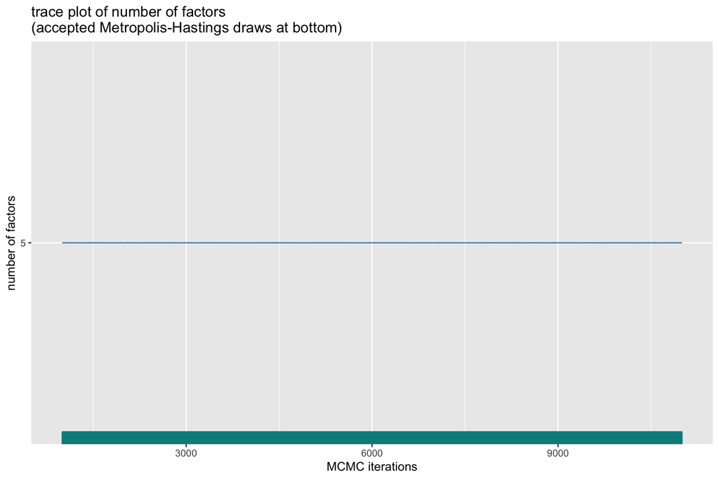

```
## Press <Enter> to show next graph...
```

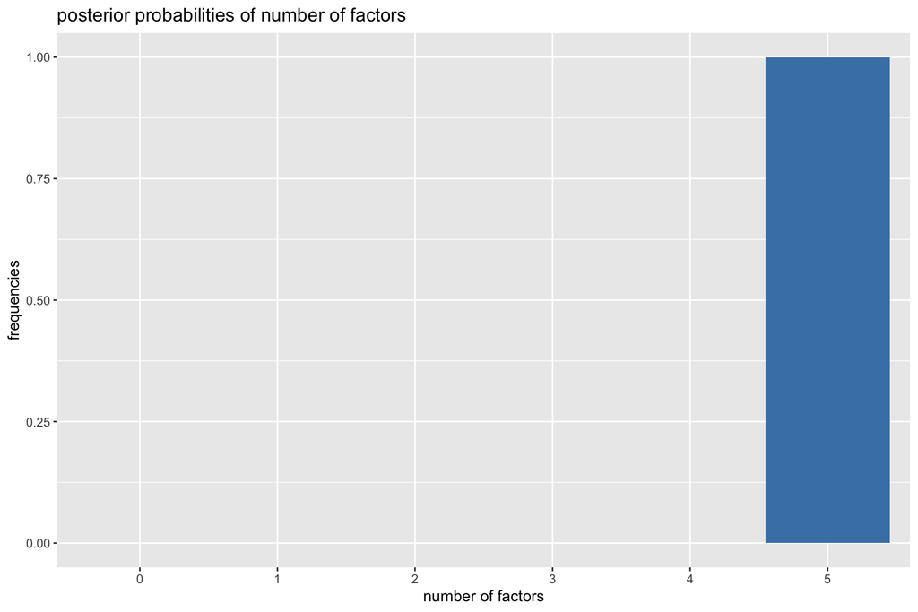

```
## Press <Enter> to show next graph...
```

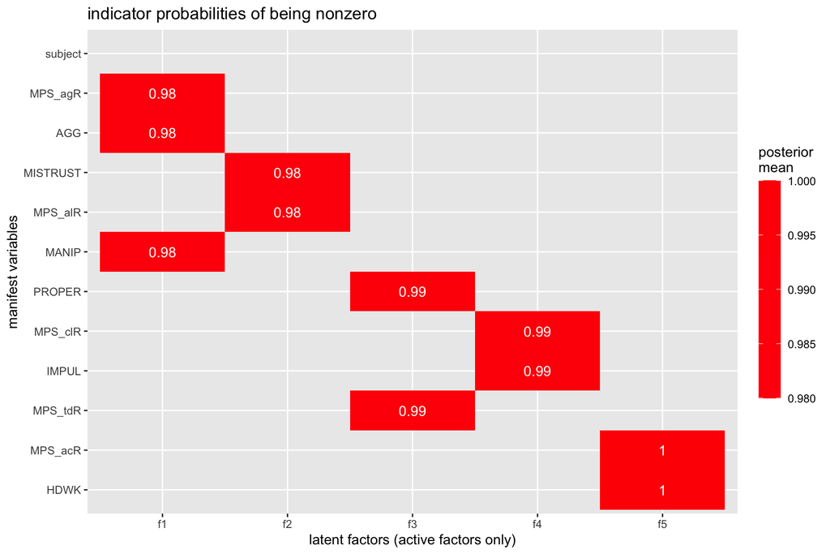

```
## Press <Enter> to show next graph...
```

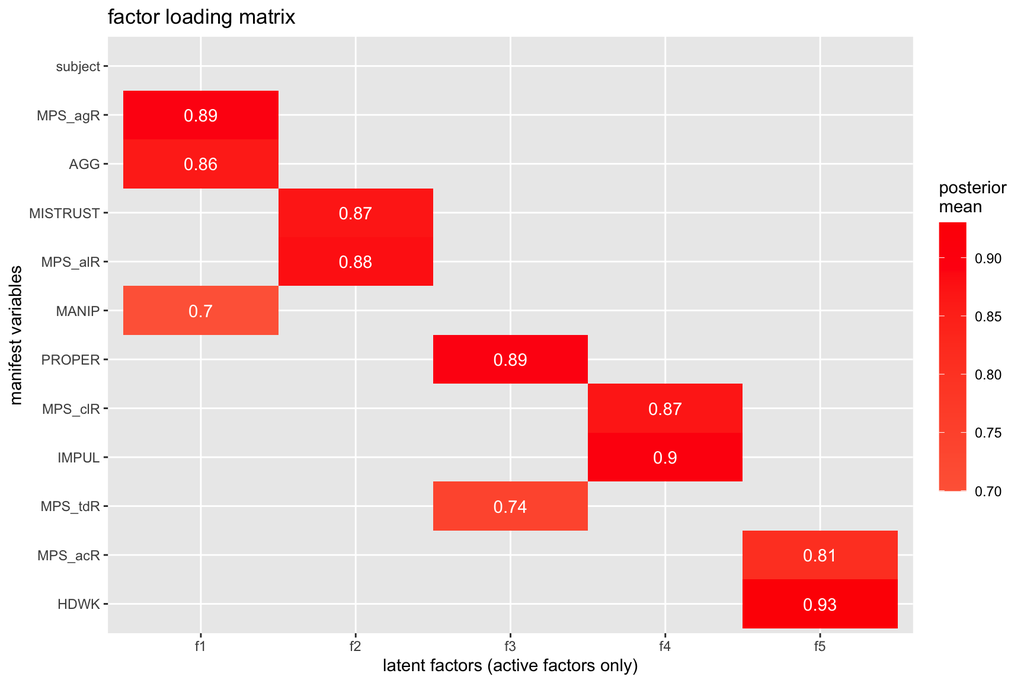

```
## Press <Enter> to show next graph...
```

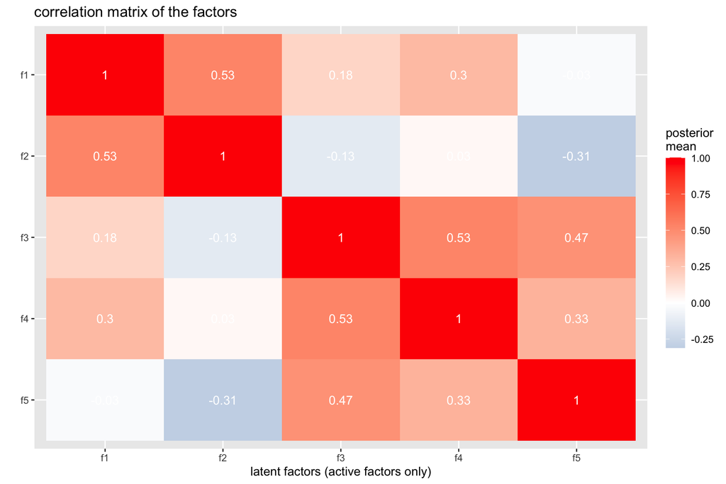

```r
mcmc <- post.column.switch(mcmc)
mcmc <- post.sign.switch(mcmc)
plot(mcmc)
```

```r
#here's a three-factor solution that is more reasonable (requires 3 indicators per factor)
mcmc3 <- befa(tofactor, iter=10000, Kmax=3, Nid=3)
```

```
## starting MCMC sampling...
##     5%
## done with burn-in period
##    10%
##    15%
##    20%
##    25%
##    30%
##    35%
##    40%
##    45%
##    50%
##    55%
##    60%
##    65%
##    70%
##    75%
##    80%
##    85%
##    90%
##    95%
##   100%
## done with sampling!
```

```r
mcmc3 <- post.column.switch(mcmc3)
```

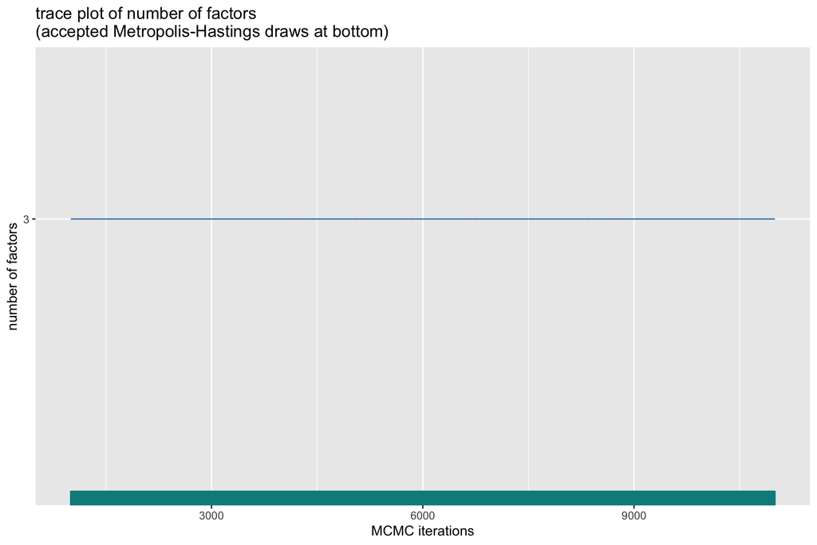

```
## Press <Enter> to show next graph...
```

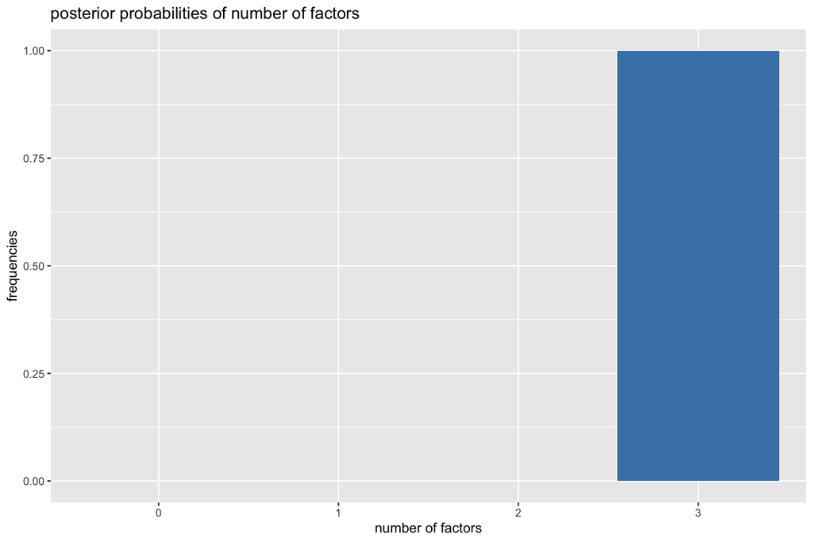

```
## Press <Enter> to show next graph...
```

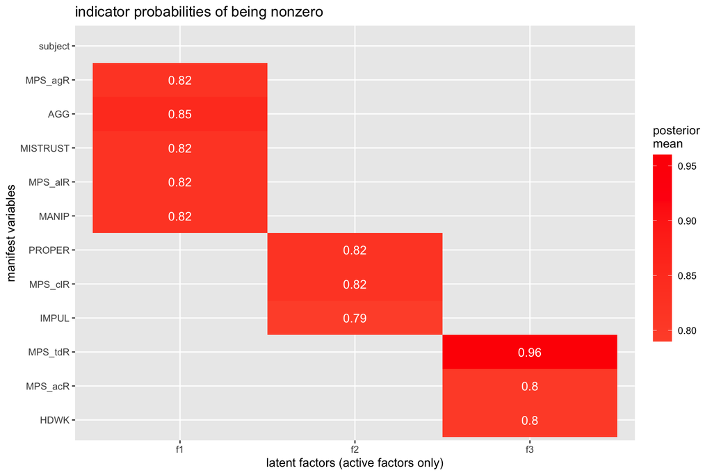

```
## Press <Enter> to show next graph...
```

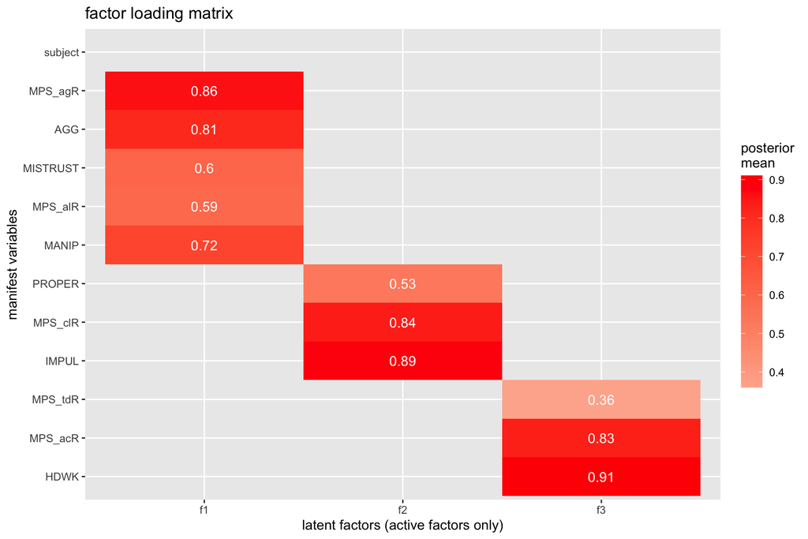

```
## Press <Enter> to show next graph...
```

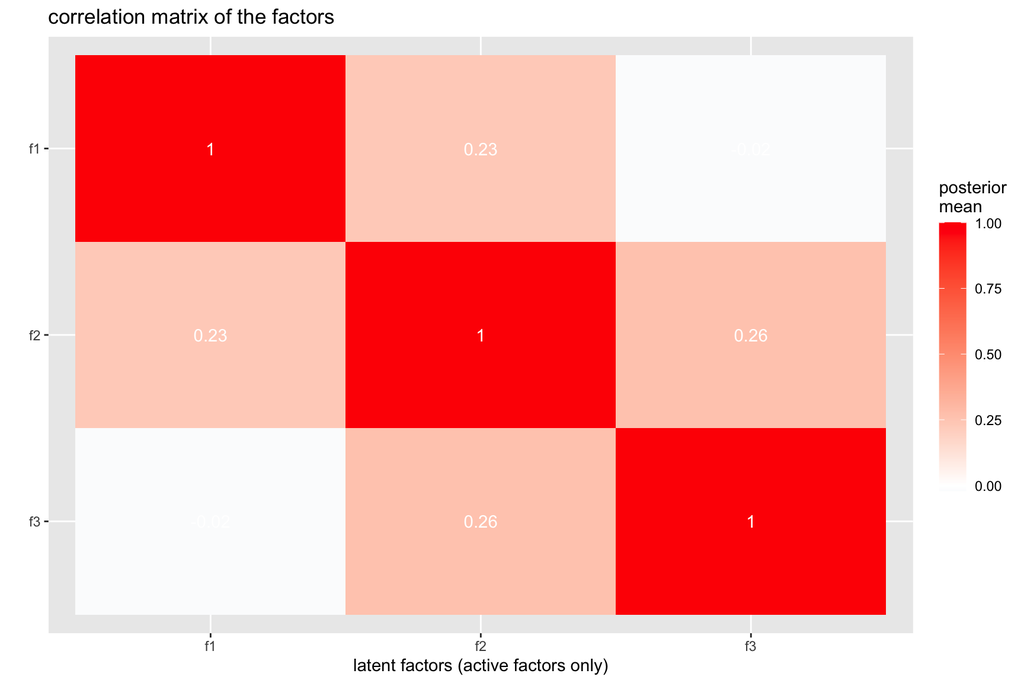

```r
mcmc3 <- post.sign.switch(mcmc3)
plot(mcmc3)
```

```r
#prepareMplusData(as.data.frame(lapply(Y, as.vector)), filename="AC_cfa_std.dat")
```

### Zelig BEFA

Not really tractable – doesn’t support rotation?!

```r
devtools::install_github('IQSS/Zelig')
library(Zelig)
z.out <- zelig(~ MPS_agR + AGG +  MISTRUST +  MPS_alR +  MANIP +
                 PROPER + MPS_clR +  IMPUL+  MPS_tdR+  MPS_acR + HDWK, factors = 2,
               model = "factor.bayes", data=tofactor)
z.out$geweke.diag()

summary(z.out)
```

### Parceling approach

Given that MPQ and SNAP are highly overlapping in content and even share the same intellectual lineage, some of the scales overlap to the point of causing problems in estimation. Rather than include a million residual correlations, let’s form two-scale parcels of MPQ and SNAP scales that overlap. To get the relative weighting of the parcels correct, z-score all scales, then use the mean of the two z-scores forming a parcel as the indicator in CFA.

Here are the couplets:

1. MISTRUST (Mistrustfulness) and MPS_alr (Alienation)
2. PROPER (Propriety) and MPS_tdr (Traditionalism)
3. IMPUL (Impulsivity, reversed) and MPS_clr (Control)
4. HDWK (Hard-working) and MPS_acr (Achievement)
5. AGG (Aggression) and MPS_agr (Aggression)

```r
AC_m <- mplusObject(
  TITLE="Antagonism and Disinhibition BSEM CFA 3+3 Parcels",
  DEFINE="
    p1=MEAN(MISTRUST MPS_alR);
    p2=MEAN(PROPER MPS_tdR);
    p3=MEAN(MPS_clR IMPUL);
    p4=MEAN(MPS_acR HDWK);
    p5=MEAN(MPS_agR AGG);
  ",
  VARIABLE="
    USEVARIABLES=MANIP p1 p2 p3 p4 p5;
    IDVARIABLE = subject;
  ",
  ANALYSIS="
    ESTIMATOR=BAYES;
    PROCESSORS=4;
    CHAINS=4;
    BITERATIONS=(30000);
  ",
  MODEL = "
    antag BY p5* ! MPS_agR AGG
      p1        ! MISTRUST MPS_alR
      MANIP;
    antag@1;

    disinhib BY
      p2*  !PROPER MPS_tdR
      p3  !MPS_clR IMPUL
      p4; !MPS_acR HDWK;
    disinhib@1;

    antag WITH disinhib;",
  SAVEDATA = "
    FILE = AC_bsem_cfa_parcel_fscores.dat;
    SAVE = FSCORES(5000);
  ",
  OUTPUT ="
    TECH1 TECH8 STANDARDIZED MODINDICES (10);
  ",
  rdata=tofactor
)

mres <- mplusModeler(AC_m, modelout = file.path(basedir, "Code", "factor_structure", "AC_bsem_cfa_parcel.inp"),
                     hashfilename = FALSE, run=TRUE,
                     Mplus_command = mpluscmd)
```

```
##
## Running model: AC_bsem_cfa_parcel.inp
## System command: cd "/Users/mnh5174/Data_Analysis/PD_Inhibition_DDM/Code/factor_structure" && "/Users/mnh5174/Applications/Mplus/mplus" "AC_bsem_cfa_parcel.inp"
## Reading model:  ~/Data_Analysis/PD_Inhibition_DDM/Code/factor_structure/AC_bsem_cfa_parcel.out
```

```r
summary(mres)
```

```
##  Antagonism and Disinhibition BSEM CFA 3+3 ParcelsEstimated using BAYES
## Number of obs: 104, number of (free) parameters: 19
##
## Fit Indices:
##
## CFI = 0.888, TLI = 0.8, SRMR = NA
## RMSEA = 0.134, 90% CI [0.089, 0.179], p < .05 = 0.001
## AIC = NA, BIC = 1653.609
```

```r
kable(mres$results$parameters$stdyx.standardized)
```

| paramHeader | param | est | posterior_sd | pval | lower_2.5ci | upper_2.5ci | sig |
| --- | --- | --- | --- | --- | --- | --- | --- |
| ANTAG.BY | P5 | 0.790 | 0.077 | 0.000 | 0.626 | 0.930 | TRUE |
| ANTAG.BY | P1 | 0.582 | 0.083 | 0.000 | 0.401 | 0.725 | TRUE |
| ANTAG.BY | MANIP | 0.802 | 0.077 | 0.000 | 0.636 | 0.939 | TRUE |
| DISINHIB.BY | P2 | 0.672 | 0.125 | 0.000 | 0.417 | 0.911 | TRUE |
| DISINHIB.BY | P3 | 0.671 | 0.127 | 0.000 | 0.420 | 0.918 | TRUE |
| DISINHIB.BY | P4 | 0.459 | 0.112 | 0.000 | 0.225 | 0.663 | TRUE |
| ANTAG.WITH | DISINHIB | 0.236 | 0.139 | 0.051 | -0.048 | 0.494 | FALSE |
| Intercepts | MANIP | -0.002 | 0.098 | 0.491 | -0.197 | 0.188 | FALSE |
| Intercepts | P1 | -0.002 | 0.098 | 0.493 | -0.193 | 0.191 | FALSE |
| Intercepts | P2 | -0.002 | 0.098 | 0.494 | -0.193 | 0.192 | FALSE |
| Intercepts | P3 | -0.002 | 0.099 | 0.494 | -0.194 | 0.193 | FALSE |
| Intercepts | P4 | -0.002 | 0.098 | 0.493 | -0.194 | 0.190 | FALSE |
| Intercepts | P5 | -0.002 | 0.098 | 0.492 | -0.196 | 0.189 | FALSE |
| Variances | ANTAG | 1.000 | 0.000 | 0.000 | 1.000 | 1.000 | FALSE |
| Variances | DISINHIB | 1.000 | 0.000 | 0.000 | 1.000 | 1.000 | FALSE |
| Residual.Variances | MANIP | 0.356 | 0.122 | 0.000 | 0.119 | 0.596 | TRUE |
| Residual.Variances | P1 | 0.662 | 0.094 | 0.000 | 0.474 | 0.839 | TRUE |
| Residual.Variances | P2 | 0.548 | 0.167 | 0.000 | 0.169 | 0.826 | TRUE |
| Residual.Variances | P3 | 0.550 | 0.170 | 0.000 | 0.158 | 0.824 | TRUE |
| Residual.Variances | P4 | 0.789 | 0.101 | 0.000 | 0.560 | 0.949 | TRUE |
| Residual.Variances | P5 | 0.376 | 0.120 | 0.000 | 0.135 | 0.609 | TRUE |

```r
write.csv(mres$results$savedata, file="AC_bsem_cfa_parcel_savedata.csv", row.names=FALSE)
```

In MLR, there is a meaningful cross-loading of P1 onto disinhib. Test this in BSEM, too.

```r
AC_m_mod <- mplusObject(
  TITLE="Antagonism and Disinhibition BSEM CFA 3+3 Parcels Modindex",
  DEFINE="
    p1=MEAN(MISTRUST MPS_alR);
    p2=MEAN(PROPER MPS_tdR);
    p3=MEAN(MPS_clR IMPUL);
    p4=MEAN(MPS_acR HDWK);
    p5=MEAN(MPS_agR AGG);
  ",
  VARIABLE="
    USEVARIABLES=MANIP p1 p2 p3 p4 p5;
    IDVARIABLE = subject;
  ",
  ANALYSIS="
    ESTIMATOR=BAYES;
    PROCESSORS=4;
    CHAINS=4;
    BITERATIONS=(30000);
  ",
  MODEL = "
    antag BY p5* ! MPS_agR AGG
      p1        ! MISTRUST MPS_alR
      MANIP;
    antag@1;

    disinhib BY
      p2*  !PROPER MPS_tdR
      p3  !MPS_clR IMPUL
      p4; !MPS_acR HDWK;
    disinhib@1;

    antag WITH disinhib;

    disinhib BY P1; !sig mod index
  ",
  SAVEDATA = "
    FILE = AC_bsem_cfa_parcel_mod_fscores.dat;
    SAVE = FSCORES(5000);
  ",
  OUTPUT ="
    TECH1 TECH8 STANDARDIZED MODINDICES (10);
  ",
  rdata=tofactor
)

mres <- mplusModeler(AC_m_mod, modelout = file.path(basedir, "Code", "factor_structure", "AC_bsem_cfa_parcel_mod.inp"),
                     hashfilename = FALSE, run=TRUE,
                     Mplus_command = mpluscmd)
```

```
##
## Running model: AC_bsem_cfa_parcel_mod.inp
## System command: cd "/Users/mnh5174/Data_Analysis/PD_Inhibition_DDM/Code/factor_structure" && "/Users/mnh5174/Applications/Mplus/mplus" "AC_bsem_cfa_parcel_mod.inp"
## Reading model:  ~/Data_Analysis/PD_Inhibition_DDM/Code/factor_structure/AC_bsem_cfa_parcel_mod.out
```

```r
summary(mres)
```

```
##  Antagonism and Disinhibition BSEM CFA 3+3 Parcels ModindexEstimated using BAYES
## Number of obs: 104, number of (free) parameters: 20
##
## Fit Indices:
##
## CFI = 0.939, TLI = 0.869, SRMR = NA
## RMSEA = 0.108, 90% CI [0, 0.172], p < .05 = 0.125
## AIC = NA, BIC = 1649.684
```

```r
kable(mres$results$parameters$stdyx.standardized)
```

| paramHeader | param | est | posterior_sd | pval | lower_2.5ci | upper_2.5ci | sig |
| --- | --- | --- | --- | --- | --- | --- | --- |
| ANTAG.BY | P5 | 0.794 | 0.070 | 0.000 | 0.640 | 0.917 | TRUE |
| ANTAG.BY | P1 | 0.690 | 0.097 | 0.000 | 0.500 | 0.883 | TRUE |
| ANTAG.BY | MANIP | 0.788 | 0.071 | 0.000 | 0.634 | 0.913 | TRUE |
| DISINHIB.BY | P2 | 0.653 | 0.107 | 0.000 | 0.426 | 0.845 | TRUE |
| DISINHIB.BY | P3 | 0.657 | 0.109 | 0.000 | 0.428 | 0.862 | TRUE |
| DISINHIB.BY | P4 | 0.508 | 0.113 | 0.000 | 0.269 | 0.711 | TRUE |
| DISINHIB.BY | P1 | -0.319 | 0.121 | 0.003 | -0.560 | -0.087 | TRUE |
| ANTAG.WITH | DISINHIB | 0.301 | 0.140 | 0.020 | 0.014 | 0.559 | TRUE |
| Intercepts | MANIP | 0.001 | 0.099 | 0.498 | -0.193 | 0.194 | FALSE |
| Intercepts | P1 | 0.000 | 0.098 | 0.499 | -0.192 | 0.193 | FALSE |
| Intercepts | P2 | -0.001 | 0.098 | 0.497 | -0.192 | 0.192 | FALSE |
| Intercepts | P3 | 0.000 | 0.098 | 0.499 | -0.192 | 0.192 | FALSE |
| Intercepts | P4 | -0.001 | 0.098 | 0.497 | -0.193 | 0.193 | FALSE |
| Intercepts | P5 | 0.000 | 0.098 | 0.499 | -0.194 | 0.193 | FALSE |
| Variances | ANTAG | 1.000 | 0.000 | 0.000 | 1.000 | 1.000 | FALSE |
| Variances | DISINHIB | 1.000 | 0.000 | 0.000 | 1.000 | 1.000 | FALSE |
| Residual.Variances | MANIP | 0.379 | 0.110 | 0.000 | 0.167 | 0.598 | TRUE |
| Residual.Variances | P1 | 0.544 | 0.108 | 0.000 | 0.332 | 0.752 | TRUE |
| Residual.Variances | P2 | 0.574 | 0.138 | 0.000 | 0.285 | 0.819 | TRUE |
| Residual.Variances | P3 | 0.568 | 0.141 | 0.000 | 0.258 | 0.817 | TRUE |
| Residual.Variances | P4 | 0.742 | 0.113 | 0.000 | 0.494 | 0.927 | TRUE |
| Residual.Variances | P5 | 0.370 | 0.109 | 0.000 | 0.158 | 0.590 | TRUE |

```r
write.csv(mres$results$savedata, file="AC_bsem_cfa_parcel_mod_savedata.csv", row.names=FALSE)
```

```r
#mplus with and without corr -- not currently a focus
nocorr <- readModels("/Users/mnh5174/Data_Analysis/PD_Inhibition_DDM/Code/factor_structure/AC_cfa_manual_noresidcorr.out")
withcorr <- readModels("/Users/mnh5174/Data_Analysis/PD_Inhibition_DDM/Code/factor_structure/AC_cfa_manual.out")
compareModels(nocorr, withcorr, compare="stdyx.standardized")
```

## Dominance model

```r
tofactor <- self_reps %>% dplyr::select(subject, POSTEMP, EXHIB, ENTITL, DETACH, MPS_wbR, MPS_spR, MPS_scR) %>%
  mutate(MPS_scR=-1*MPS_scR) %>% #rescore in direction of detachment (higher scores are bad)
  mutate_at(vars(-subject), list(~as.vector(scale(.))))

Dom_m <- mplusObject(
  TITLE="Dominance BSEM CFA",
  VARIABLE="
    USEVARIABLES=POSTEMP EXHIB ENTITL DETACH MPS_wbR MPS_spR MPS_scR;
    IDVARIABLE = subject;
  ",
  ANALYSIS="
    ESTIMATOR=BAYES;
    PROCESSORS=4;
    CHAINS=4;
    BITERATIONS=(15000);
  ",
  MODEL = "
    agentic BY MPS_spR* EXHIB ENTITL POSTEMP MPS_wbR;
    agentic@1;

    affiliat BY MPS_scR* DETACH;
    affiliat@1;

    agentic WITH affiliat;

    MPS_SPR WITH EXHIB;
    !DETACH@0;  !heywood case in MLR, okay in Bayes (force positive variance)
  ",
  SAVEDATA = "
    FILE = Dom_bsem_cfa_fscores.dat;
    SAVE = FSCORES(5000);
  ",
  OUTPUT ="
    TECH1 TECH8 STANDARDIZED MODINDICES (10);
  ",
  rdata=tofactor
)

mres <- mplusModeler(Dom_m, modelout = file.path(basedir, "Code", "factor_structure", "Dom_bsem_cfa.inp"),
                     hashfilename = FALSE, run=TRUE,
                     Mplus_command = mpluscmd)
```

```
##
## Running model: Dom_bsem_cfa.inp
## System command: cd "/Users/michael/Data_Analysis/PD_Inhibition_DDM/Code/factor_structure" && "/Applications/Mplus/mplus" "Dom_bsem_cfa.inp"
## Reading model:  ~/Data_Analysis/PD_Inhibition_DDM/Code/factor_structure/Dom_bsem_cfa.out
```

```r
summary(mres)
```

```
##  Dominance BSEM CFAEstimated using BAYES
## Number of obs: 104, number of (free) parameters: 23
##
## Fit Indices:
##
## CFI = 0.954, TLI = 0.926, SRMR = NA
## RMSEA = 0.11, 90% CI [0.066, 0.151], p < .05 = 0.011
## AIC = NA, BIC = 1819.135
```

```r
kable(mres$results$parameters$stdyx.standardized)
```

| paramHeader | param | est | posterior_sd | pval | lower_2.5ci | upper_2.5ci | sig |
| --- | --- | --- | --- | --- | --- | --- | --- |
| AGENTIC.BY | MPS_SPR | 0.451 | 0.086 | 0.000 | 0.266 | 0.605 | TRUE |
| AGENTIC.BY | EXHIB | 0.456 | 0.087 | 0.000 | 0.272 | 0.610 | TRUE |
| AGENTIC.BY | ENTITL | 0.359 | 0.094 | 0.000 | 0.162 | 0.530 | TRUE |
| AGENTIC.BY | POSTEMP | 0.911 | 0.039 | 0.000 | 0.824 | 0.978 | TRUE |
| AGENTIC.BY | MPS_WBR | 0.866 | 0.041 | 0.000 | 0.777 | 0.936 | TRUE |
| AFFILIAT.BY | MPS_SCR | 0.846 | 0.038 | 0.000 | 0.769 | 0.916 | TRUE |
| AFFILIAT.BY | DETACH | 0.976 | 0.027 | 0.000 | 0.899 | 0.999 | TRUE |
| AGENTIC.WITH | AFFILIAT | -0.556 | 0.080 | 0.000 | -0.693 | -0.380 | TRUE |
| MPS_SPR.WITH | EXHIB | 0.565 | 0.071 | 0.000 | 0.408 | 0.688 | TRUE |
| Intercepts | POSTEMP | 0.004 | 0.099 | 0.486 | -0.192 | 0.196 | FALSE |
| Intercepts | EXHIB | 0.001 | 0.098 | 0.498 | -0.194 | 0.191 | FALSE |
| Intercepts | ENTITL | 0.001 | 0.099 | 0.498 | -0.193 | 0.195 | FALSE |
| Intercepts | DETACH | -0.005 | 0.102 | 0.480 | -0.199 | 0.202 | FALSE |
| Intercepts | MPS_WBR | 0.003 | 0.099 | 0.487 | -0.193 | 0.196 | FALSE |
| Intercepts | MPS_SPR | 0.001 | 0.099 | 0.496 | -0.194 | 0.195 | FALSE |
| Intercepts | MPS_SCR | -0.003 | 0.101 | 0.486 | -0.196 | 0.195 | FALSE |
| Variances | AGENTIC | 1.000 | 0.000 | 0.000 | 1.000 | 1.000 | FALSE |
| Variances | AFFILIAT | 1.000 | 0.000 | 0.000 | 1.000 | 1.000 | FALSE |
| Residual.Variances | POSTEMP | 0.171 | 0.071 | 0.000 | 0.044 | 0.321 | TRUE |
| Residual.Variances | EXHIB | 0.792 | 0.077 | 0.000 | 0.628 | 0.926 | TRUE |
| Residual.Variances | ENTITL | 0.871 | 0.066 | 0.000 | 0.719 | 0.974 | TRUE |
| Residual.Variances | DETACH | 0.047 | 0.051 | 0.000 | 0.002 | 0.192 | TRUE |
| Residual.Variances | MPS_WBR | 0.251 | 0.070 | 0.000 | 0.124 | 0.397 | TRUE |
| Residual.Variances | MPS_SPR | 0.796 | 0.076 | 0.000 | 0.634 | 0.929 | TRUE |
| Residual.Variances | MPS_SCR | 0.284 | 0.063 | 0.000 | 0.161 | 0.409 | TRUE |

```r
write.csv(mres$results$savedata, file="Dom_bsem_cfa_savedata.csv", row.names=FALSE)
```

## Dominance parcel CFA

The dominance model is a bit fragile and has started falling apart in MSEMs.

Try the same parceling approach

```r
Dom_m <- mplusObject(
  TITLE="Dominance BSEM CFA Parceled",
  DEFINE="
    p1 = MEAN(MPS_spR EXHIB);
    p2 = MEAN(POSTEMP MPS_wbR);
  ",
  VARIABLE="
    USEVARIABLES=ENTITL DETACH MPS_scR p1 p2;
    IDVARIABLE = subject;
  ",
  ANALYSIS="
    ESTIMATOR=BAYES;
    PROCESSORS=4;
    CHAINS=4;
    BITERATIONS=(15000);
  ",
  MODEL = "
    agentic BY p1* ENTITL p2;
    agentic @1;

    affiliat BY MPS_scR* DETACH;
    affiliat@1;

    agentic WITH affiliat;
    !DETACH@0;  !heywood case in MLR, okay in Bayes (force positive variance)
  ",
  SAVEDATA = "
    FILE = Dom_bsem_cfa_parcel_fscores.dat;
    SAVE = FSCORES(5000);
  ",
  OUTPUT ="
    TECH1 TECH8 STANDARDIZED;
  ",
  rdata=tofactor
)
```

```
## R variables selected automatically as any variable name that
## occurs in the MODEL, VARIABLE, or DEFINE section.
```

```r
mres <- mplusModeler(Dom_m, modelout = file.path(basedir, "Code", "factor_structure", "Dom_bsem_cfa_parcel.inp"),
                     hashfilename = FALSE, run=TRUE,
                     Mplus_command = mpluscmd)
```

```
## When hashfilename = FALSE, writeData cannot be 'ifmissing', setting to 'always'
```

```
## Wrote model to: ~/Data_Analysis/PD_Inhibition_DDM/Code/factor_structure/Dom_bsem_cfa_parcel.inp
```

```
## Wrote data to: ~/Data_Analysis/PD_Inhibition_DDM/Code/factor_structure/Dom_bsem_cfa_parcel.dat
```

```
## The file(s)
##  'Dom_bsem_cfa_parcel.dat'
## currently exist(s) and will be overwritten
```

```
##
## Running model: Dom_bsem_cfa_parcel.inp
## System command: cd "/Users/michael/Data_Analysis/PD_Inhibition_DDM/Code/factor_structure" && "/Applications/Mplus/mplus" "Dom_bsem_cfa_parcel.inp"
## Reading model:  ~/Data_Analysis/PD_Inhibition_DDM/Code/factor_structure/Dom_bsem_cfa_parcel.out
```

```r
summary(mres)
```

```
##  Dominance BSEM CFA ParceledEstimated using BAYES
## Number of obs: 104, number of (free) parameters: 16
##
## Fit Indices:
##
## CFI = 0.933, TLI = 0.794, SRMR = NA
## RMSEA = 0.198, 90% CI [0.113, 0.311], p < .05 = 0.002
## AIC = NA, BIC = 1323.172
```

```r
kable(mres$results$parameters$stdyx.standardized)
```

| paramHeader | param | est | posterior_sd | pval | lower_2.5ci | upper_2.5ci | sig |
| --- | --- | --- | --- | --- | --- | --- | --- |
| AGENTIC.BY | P1 | 0.627 | 0.117 | 0.000 | 0.348 | 0.819 | TRUE |
| AGENTIC.BY | ENTITL | 0.407 | 0.138 | 0.011 | 0.059 | 0.614 | TRUE |
| AGENTIC.BY | P2 | 0.737 | 0.113 | 0.000 | 0.473 | 0.929 | TRUE |
| AFFILIAT.BY | MPS_SCR | 0.842 | 0.035 | 0.000 | 0.767 | 0.903 | TRUE |
| AFFILIAT.BY | DETACH | 0.983 | 0.023 | 0.000 | 0.917 | 1.000 | TRUE |
| AGENTIC.WITH | AFFILIAT | -0.620 | 0.145 | 0.000 | -0.990 | -0.397 | TRUE |
| Intercepts | ENTITL | 0.000 | 0.098 | 0.498 | -0.191 | 0.191 | FALSE |
| Intercepts | DETACH | -0.001 | 0.098 | 0.498 | -0.195 | 0.190 | FALSE |
| Intercepts | MPS_SCR | 0.000 | 0.098 | 0.498 | -0.191 | 0.194 | FALSE |
| Intercepts | P1 | 0.000 | 0.098 | 0.498 | -0.191 | 0.193 | FALSE |
| Intercepts | P2 | 0.001 | 0.098 | 0.497 | -0.191 | 0.194 | FALSE |
| Variances | AGENTIC | 1.000 | 0.000 | 0.000 | 1.000 | 1.000 | FALSE |
| Variances | AFFILIAT | 1.000 | 0.000 | 0.000 | 1.000 | 1.000 | FALSE |
| Residual.Variances | ENTITL | 0.834 | 0.098 | 0.000 | 0.623 | 0.995 | TRUE |
| Residual.Variances | DETACH | 0.035 | 0.044 | 0.000 | 0.001 | 0.160 | TRUE |
| Residual.Variances | MPS_SCR | 0.291 | 0.058 | 0.000 | 0.184 | 0.412 | TRUE |
| Residual.Variances | P1 | 0.607 | 0.139 | 0.000 | 0.329 | 0.879 | TRUE |
| Residual.Variances | P2 | 0.457 | 0.160 | 0.000 | 0.136 | 0.776 | TRUE |

## Amended dominance model

Following Tim’s further exploration of the dominance analysis, drop POSTEMP and MPS_wbR as generic indicators of extraversion. This tilts the first factor more cleanly toward agentic extraversion. The model also appears to fit the data quite well. This is called Model A in Tim’s nomenclature, which I’ve preserved here.

```r
tofactor <- self_reps %>% dplyr::select(subject, EXHIB, ENTITL, DETACH, MPS_spR, MPS_scR) %>%
  mutate(MPS_scR=-1*MPS_scR) %>% #rescore in direction of detachment (higher scores are bad)
  mutate_at(vars(-subject), list(~as.vector(scale(.))))

Dom_m <- mplusObject(
  TITLE="Dominance BSEM CFA Model A amendment",
  VARIABLE="
    USEVARIABLES=EXHIB ENTITL DETACH MPS_spR MPS_scR;
    IDVARIABLE = subject;
  ",
  ANALYSIS="
    ESTIMATOR=BAYES;
    PROCESSORS=4;
    CHAINS=4;
    BITERATIONS=(35000);
  ",
  MODEL = "
    agentic BY MPS_spR* EXHIB ENTITL;
    agentic@1;

    affiliat BY MPS_scR* DETACH;
    affiliat@1;

    agentic WITH affiliat;
  ",
  SAVEDATA = "
    FILE = Dom_bsem_cfa_modela_fscores.dat;
    SAVE = FSCORES(5000);
  ",
  OUTPUT ="
    TECH1 TECH8 STANDARDIZED MODINDICES (10);
  ",
  rdata=tofactor
)

mres <- mplusModeler(Dom_m, modelout = file.path(basedir, "Code", "factor_structure", "Dom_bsem_cfa_modela.inp"),
                     hashfilename = FALSE, run=TRUE,
                     Mplus_command = mpluscmd)
```

```
##
## Running model: Dom_bsem_cfa_modela.inp
## System command: cd "/Users/michael/Data_Analysis/PD_Inhibition_DDM/Code/factor_structure" && "/Applications/Mplus/mplus" "Dom_bsem_cfa_modela.inp"
## Reading model:  ~/Data_Analysis/PD_Inhibition_DDM/Code/factor_structure/Dom_bsem_cfa_modela.out
```

```r
summary(mres)
```

```
##  Dominance BSEM CFA Model A amendmentEstimated using BAYES
## Number of obs: 104, number of (free) parameters: 16
##
## Fit Indices:
##
## CFI = 0.99, TLI = 0.98, SRMR = NA
## RMSEA = 0.063, 90% CI [0, 0.161], p < .05 = 0.446
## AIC = NA, BIC = 1330.58
```

```r
kable(mres$results$parameters$stdyx.standardized)
```

| paramHeader | param | est | posterior_sd | pval | lower_2.5ci | upper_2.5ci | sig |
| --- | --- | --- | --- | --- | --- | --- | --- |
| AGENTIC.BY | MPS_SPR | 0.712 | 0.069 | 0.000 | 0.567 | 0.837 | TRUE |
| AGENTIC.BY | EXHIB | 0.920 | 0.060 | 0.000 | 0.771 | 0.996 | TRUE |
| AGENTIC.BY | ENTITL | 0.443 | 0.089 | 0.000 | 0.255 | 0.604 | TRUE |
| AFFILIAT.BY | MPS_SCR | 0.847 | 0.040 | 0.000 | 0.768 | 0.928 | TRUE |
| AFFILIAT.BY | DETACH | 0.974 | 0.032 | 0.000 | 0.882 | 0.999 | TRUE |
| AGENTIC.WITH | AFFILIAT | -0.438 | 0.095 | 0.000 | -0.605 | -0.235 | TRUE |
| Intercepts | EXHIB | 0.000 | 0.097 | 0.499 | -0.191 | 0.188 | FALSE |
| Intercepts | ENTITL | -0.001 | 0.098 | 0.497 | -0.194 | 0.190 | FALSE |
| Intercepts | DETACH | 0.000 | 0.100 | 0.499 | -0.192 | 0.204 | FALSE |
| Intercepts | MPS_SPR | -0.001 | 0.098 | 0.497 | -0.192 | 0.191 | FALSE |
| Intercepts | MPS_SCR | 0.001 | 0.100 | 0.498 | -0.194 | 0.201 | FALSE |
| Variances | AGENTIC | 1.000 | 0.000 | 0.000 | 1.000 | 1.000 | FALSE |
| Variances | AFFILIAT | 1.000 | 0.000 | 0.000 | 1.000 | 1.000 | FALSE |
| Residual.Variances | EXHIB | 0.154 | 0.107 | 0.000 | 0.009 | 0.405 | TRUE |
| Residual.Variances | ENTITL | 0.804 | 0.077 | 0.000 | 0.636 | 0.935 | TRUE |
| Residual.Variances | DETACH | 0.051 | 0.060 | 0.000 | 0.002 | 0.222 | TRUE |
| Residual.Variances | MPS_SPR | 0.494 | 0.097 | 0.000 | 0.299 | 0.679 | TRUE |
| Residual.Variances | MPS_SCR | 0.283 | 0.068 | 0.000 | 0.138 | 0.410 | TRUE |

```r
write.csv(mres$results$savedata, file="Dom_bsem_cfa_modela_savedata.csv", row.names=FALSE)
```

## Add affiliative extraversion to Antag + Disinhib model

```r
tofactor <- self_reps %>%
  dplyr::select(subject, EXHIB, ENTITL, DETACH, MPS_spR, MPS_scR,
                MPS_agR, AGG, MISTRUST, MPS_alR, MANIP,
                PROPER, MPS_clR, IMPUL, MPS_tdR, MPS_acR, HDWK) %>%
  mutate(MPS_scR=-1*MPS_scR) %>% #rescore in direction of detachment (higher scores are bad)
  mutate(IMPUL =-1*IMPUL) %>% #score toward constraint to make loadings upright
  mutate_at(vars(-subject), list(~as.vector(scale(.))))

Combo_m <- mplusObject(
  TITLE="Aff Extraversion, Antag, disinhib combination",
  DEFINE="
    p1=MEAN(MISTRUST MPS_alR);
    p2=MEAN(PROPER MPS_tdR);
    p3=MEAN(MPS_clR IMPUL);
    p4=MEAN(MPS_acR HDWK);
    p5=MEAN(MPS_agR AGG);
  ",
  VARIABLE="
    USEVARIABLES=DETACH MPS_scR
      MANIP p1 p2 p3 p4 p5;
    IDVARIABLE = subject;
  ",
  ANALYSIS="
    ESTIMATOR=BAYES;
    PROCESSORS=4;
    CHAINS=4;
    BITERATIONS=(35000);
  ",
  MODEL = "
    affiliat BY MPS_scR* DETACH;
    affiliat@1;

    antag BY p5* ! MPS_agR AGG
      p1        ! MISTRUST MPS_alR
      MANIP;
    antag@1;

    disinhib BY
      p2*  !PROPER MPS_tdR
      p3   !MPS_clR IMPUL
      p4;  !MPS_acR HDWK;
    disinhib@1;

    antag disinhib affiliat WITH
      antag disinhib affiliat;

    !these were identified in the 4-factor model using MLR
    AFFILIAT BY P1; !sig modification index

    !this one comes from the two-factor model, but seems unimportant for 4-factor.
    !disinhib BY P1; !mod index
  ",
  OUTPUT ="
    TECH1 TECH8 STANDARDIZED MODINDICES (10);
  ",
  rdata=tofactor
)
```

```
## R variables selected automatically as any variable name that
## occurs in the MODEL, VARIABLE, or DEFINE section.
```

```r
mres <- mplusModeler(Combo_m, modelout = file.path(basedir, "Code", "factor_structure", "Antag_addAff.inp"),
                     hashfilename = FALSE, run=TRUE,
                     Mplus_command = mpluscmd)
```

```
## When hashfilename = FALSE, writeData cannot be 'ifmissing', setting to 'always'
```

```
## Wrote model to: ~/Data_Analysis/PD_Inhibition_DDM/Code/factor_structure/Antag_addAff.inp
```

```
## Wrote data to: ~/Data_Analysis/PD_Inhibition_DDM/Code/factor_structure/Antag_addAff.dat
```

```
## The file(s)
##  'Antag_addAff.dat'
## currently exist(s) and will be overwritten
```

```
##
## Running model: Antag_addAff.inp
## System command: cd "/Users/mnh5174/Data_Analysis/PD_Inhibition_DDM/Code/factor_structure" && "/Applications/Mplus/mplus" "Antag_addAff.inp"
```

```
## Reading model:  ~/Data_Analysis/PD_Inhibition_DDM/Code/factor_structure/Antag_addAff.out
```

```r
summary(mres)
```

```
##  Aff Extraversion, Antag, Inhib combinationEstimated using BAYES
## Number of obs: 104, number of (free) parameters: 28
##
## Fit Indices:
##
## CFI = 0.958, TLI = 0.927, SRMR = NA
## RMSEA = 0.086, 90% CI [0.024, 0.129], p < .05 = 0.13
## AIC = NA, BIC = 2118.949
```

```r
kable(mres$results$parameters$stdyx.standardized)
```

| paramHeader | param | est | posterior_sd | pval | lower_2.5ci | upper_2.5ci | sig |
| --- | --- | --- | --- | --- | --- | --- | --- |
| AFFILIAT.BY | MPS_SCR | 0.907 | 0.040 | 0.000 | 0.821 | 0.979 | TRUE |
| AFFILIAT.BY | DETACH | 0.908 | 0.040 | 0.000 | 0.821 | 0.980 | TRUE |
| AFFILIAT.BY | P1 | 0.416 | 0.087 | 0.000 | 0.236 | 0.575 | TRUE |
| ANTAG.BY | P5 | 0.798 | 0.072 | 0.000 | 0.642 | 0.929 | TRUE |
| ANTAG.BY | P1 | 0.431 | 0.090 | 0.000 | 0.244 | 0.597 | TRUE |
| ANTAG.BY | MANIP | 0.793 | 0.071 | 0.000 | 0.637 | 0.919 | TRUE |
| INHIB.BY | P2 | 0.624 | 0.113 | 0.000 | 0.394 | 0.835 | TRUE |
| INHIB.BY | P3 | 0.727 | 0.114 | 0.000 | 0.485 | 0.930 | TRUE |
| INHIB.BY | P4 | 0.438 | 0.111 | 0.000 | 0.203 | 0.637 | TRUE |
| ANTAG.WITH | INHIB | -0.295 | 0.140 | 0.022 | -0.551 | -0.007 | TRUE |
| ANTAG.WITH | AFFILIAT | 0.372 | 0.110 | 0.001 | 0.143 | 0.573 | TRUE |
| INHIB.WITH | AFFILIAT | 0.243 | 0.128 | 0.030 | -0.009 | 0.484 | FALSE |
| Intercepts | DETACH | 0.001 | 0.099 | 0.494 | -0.193 | 0.193 | FALSE |
| Intercepts | MPS_SCR | 0.000 | 0.098 | 0.499 | -0.194 | 0.192 | FALSE |
| Intercepts | MANIP | 0.000 | 0.099 | 0.499 | -0.193 | 0.195 | FALSE |
| Intercepts | P1 | 0.001 | 0.099 | 0.496 | -0.192 | 0.194 | FALSE |
| Intercepts | P2 | 0.000 | 0.098 | 0.499 | -0.191 | 0.191 | FALSE |
| Intercepts | P3 | -0.001 | 0.098 | 0.495 | -0.193 | 0.192 | FALSE |
| Intercepts | P4 | 0.000 | 0.098 | 0.500 | -0.191 | 0.191 | FALSE |
| Intercepts | P5 | 0.001 | 0.099 | 0.496 | -0.194 | 0.196 | FALSE |
| Variances | AFFILIAT | 1.000 | 0.000 | 0.000 | 1.000 | 1.000 | FALSE |
| Variances | ANTAG | 1.000 | 0.000 | 0.000 | 1.000 | 1.000 | FALSE |
| Variances | INHIB | 1.000 | 0.000 | 0.000 | 1.000 | 1.000 | FALSE |
| Residual.Variances | DETACH | 0.175 | 0.072 | 0.000 | 0.040 | 0.325 | TRUE |
| Residual.Variances | MPS_SCR | 0.178 | 0.072 | 0.000 | 0.042 | 0.325 | TRUE |
| Residual.Variances | MANIP | 0.370 | 0.111 | 0.000 | 0.156 | 0.594 | TRUE |
| Residual.Variances | P1 | 0.503 | 0.079 | 0.000 | 0.360 | 0.667 | TRUE |
| Residual.Variances | P2 | 0.611 | 0.140 | 0.000 | 0.302 | 0.845 | TRUE |
| Residual.Variances | P3 | 0.471 | 0.160 | 0.000 | 0.135 | 0.765 | TRUE |
| Residual.Variances | P4 | 0.808 | 0.095 | 0.000 | 0.594 | 0.959 | TRUE |
| Residual.Variances | P5 | 0.364 | 0.114 | 0.000 | 0.137 | 0.587 | TRUE |

```r
#write.csv(mres$results$savedata, file="Combo_bsem_cfa_withmodindices_savedata.csv", row.names=FALSE)
```

## Add agentic extraversion to Antag + disinhib model

```r
tofactor <- self_reps %>%
  dplyr::select(subject, EXHIB, ENTITL, DETACH, MPS_spR, MPS_scR,
                MPS_agR, AGG, MISTRUST, MPS_alR, MANIP,
                PROPER, MPS_clR, IMPUL, MPS_tdR, MPS_acR, HDWK) %>%
  mutate(MPS_scR=-1*MPS_scR) %>% #rescore in direction of detachment (higher scores are bad)
  mutate(IMPUL =-1*IMPUL) %>% #score toward constraint to make loadings upright
  mutate_at(vars(-subject), list(~as.vector(scale(.))))

Combo_m <- mplusObject(
  TITLE="Agentic Extraversion, Antag, disinhib combination",
  DEFINE="
    p1=MEAN(MISTRUST MPS_alR);
    p2=MEAN(PROPER MPS_tdR);
    p3=MEAN(MPS_clR IMPUL);
    p4=MEAN(MPS_acR HDWK);
    p5=MEAN(MPS_agR AGG);
  ",
  VARIABLE="
    USEVARIABLES = MANIP MPS_spR EXHIB ENTITL
      p1 p2 p3 p4 p5;
    IDVARIABLE = subject;
  ",
  ANALYSIS="
    ESTIMATOR=BAYES;
    PROCESSORS=4;
    CHAINS=4;
    BITERATIONS=(35000);
  ",
  MODEL = "
    agentic BY MPS_spR* EXHIB ENTITL;
    agentic@1;

    antag BY p5* ! MPS_agR AGG
      p1        ! MISTRUST MPS_alR
      MANIP;
    antag@1;

    disinhib BY
      p2*  !PROPER MPS_tdR
      p3   !MPS_clR IMPUL
      p4;  !MPS_acR HDWK;
    disinhib@1;

    antag disinhib agentic WITH
      antag disinhib agentic;

    !two cross-loadings for disinhib suggested by MLR
    disinhib BY ENTITL;
    disinhib BY P1;
  ",
  OUTPUT ="
    TECH1 TECH8 STANDARDIZED MODINDICES (10);
  ",
  rdata=tofactor
)
```

```
## R variables selected automatically as any variable name that
## occurs in the MODEL, VARIABLE, or DEFINE section.
```

```r
mres <- mplusModeler(Combo_m, modelout = file.path(basedir, "Code", "factor_structure", "Antag_addAgen.inp"),
                     hashfilename = FALSE, run=TRUE,
                     Mplus_command = mpluscmd)
```

```
## When hashfilename = FALSE, writeData cannot be 'ifmissing', setting to 'always'
```

```
## Wrote model to: ~/Data_Analysis/PD_Inhibition_DDM/Code/factor_structure/Antag_addAgen.inp
```

```
## Wrote data to: ~/Data_Analysis/PD_Inhibition_DDM/Code/factor_structure/Antag_addAgen.dat
```

```
## The file(s)
##  'Antag_addAgen.dat'
## currently exist(s) and will be overwritten
```

```
##
## Running model: Antag_addAgen.inp
## System command: cd "/Users/mnh5174/Data_Analysis/PD_Inhibition_DDM/Code/factor_structure" && "/Applications/Mplus/mplus" "Antag_addAgen.inp"
```

```
## Reading model:  ~/Data_Analysis/PD_Inhibition_DDM/Code/factor_structure/Antag_addAgen.out
```

```r
summary(mres)
```

```
##  Agentic Extraversion, Antag, Inhib combinationEstimated using BAYES
## Number of obs: 104, number of (free) parameters: 32
##
## Fit Indices:
##
## CFI = 0.892, TLI = 0.827, SRMR = NA
## RMSEA = 0.11, 90% CI [0.082, 0.138], p < .05 = 0
## AIC = NA, BIC = 2481.624
```

```r
kable(mres$results$parameters$stdyx.standardized)
```

| paramHeader | param | est | posterior_sd | pval | lower_2.5ci | upper_2.5ci | sig |
| --- | --- | --- | --- | --- | --- | --- | --- |
| AGENTIC.BY | MPS_SPR | 0.778 | 0.068 | 0.000 | 0.631 | 0.896 | TRUE |
| AGENTIC.BY | EXHIB | 0.832 | 0.067 | 0.000 | 0.685 | 0.951 | TRUE |
| AGENTIC.BY | ENTITL | 0.633 | 0.108 | 0.000 | 0.423 | 0.850 | TRUE |
| ANTAG.BY | P5 | 0.797 | 0.071 | 0.000 | 0.641 | 0.917 | TRUE |
| ANTAG.BY | P1 | 0.670 | 0.094 | 0.000 | 0.477 | 0.848 | TRUE |
| ANTAG.BY | MANIP | 0.796 | 0.071 | 0.000 | 0.643 | 0.926 | TRUE |
| INHIB.BY | P2 | 0.682 | 0.094 | 0.000 | 0.479 | 0.846 | TRUE |
| INHIB.BY | P3 | 0.667 | 0.094 | 0.000 | 0.462 | 0.831 | TRUE |
| INHIB.BY | P4 | 0.474 | 0.105 | 0.000 | 0.249 | 0.657 | TRUE |
| INHIB.BY | ENTITL | 0.480 | 0.119 | 0.000 | 0.250 | 0.720 | TRUE |
| INHIB.BY | P1 | 0.312 | 0.114 | 0.003 | 0.088 | 0.537 | TRUE |
| ANTAG.WITH | INHIB | -0.279 | 0.136 | 0.025 | -0.530 | 0.001 | FALSE |
| ANTAG.WITH | AGENTIC | 0.375 | 0.116 | 0.001 | 0.133 | 0.585 | TRUE |
| INHIB.WITH | AGENTIC | -0.352 | 0.134 | 0.007 | -0.596 | -0.074 | TRUE |
| Intercepts | MANIP | -0.001 | 0.098 | 0.494 | -0.194 | 0.193 | FALSE |
| Intercepts | MPS_SPR | -0.001 | 0.098 | 0.494 | -0.193 | 0.192 | FALSE |
| Intercepts | EXHIB | 0.000 | 0.098 | 0.499 | -0.194 | 0.191 | FALSE |
| Intercepts | ENTITL | -0.001 | 0.098 | 0.495 | -0.194 | 0.190 | FALSE |
| Intercepts | P1 | 0.000 | 0.098 | 0.498 | -0.194 | 0.190 | FALSE |
| Intercepts | P2 | -0.001 | 0.098 | 0.498 | -0.193 | 0.191 | FALSE |
| Intercepts | P3 | 0.000 | 0.098 | 0.500 | -0.193 | 0.192 | FALSE |
| Intercepts | P4 | -0.001 | 0.097 | 0.497 | -0.190 | 0.192 | FALSE |
| Intercepts | P5 | -0.002 | 0.098 | 0.494 | -0.194 | 0.192 | FALSE |
| Variances | AGENTIC | 1.000 | 0.000 | 0.000 | 1.000 | 1.000 | FALSE |
| Variances | ANTAG | 1.000 | 0.000 | 0.000 | 1.000 | 1.000 | FALSE |
| Variances | INHIB | 1.000 | 0.000 | 0.000 | 1.000 | 1.000 | FALSE |
| Residual.Variances | MANIP | 0.366 | 0.112 | 0.000 | 0.142 | 0.586 | TRUE |
| Residual.Variances | MPS_SPR | 0.394 | 0.104 | 0.000 | 0.197 | 0.601 | TRUE |
| Residual.Variances | EXHIB | 0.308 | 0.110 | 0.000 | 0.095 | 0.531 | TRUE |
| Residual.Variances | ENTITL | 0.572 | 0.110 | 0.000 | 0.356 | 0.783 | TRUE |
| Residual.Variances | P1 | 0.561 | 0.105 | 0.000 | 0.360 | 0.768 | TRUE |
| Residual.Variances | P2 | 0.534 | 0.125 | 0.000 | 0.284 | 0.770 | TRUE |
| Residual.Variances | P3 | 0.555 | 0.122 | 0.000 | 0.309 | 0.786 | TRUE |
| Residual.Variances | P4 | 0.775 | 0.096 | 0.000 | 0.568 | 0.938 | TRUE |
| Residual.Variances | P5 | 0.365 | 0.110 | 0.000 | 0.158 | 0.589 | TRUE |

```r
#write.csv(mres$results$savedata, file="Combo_bsem_cfa_withmodindices_savedata.csv", row.names=FALSE)
```

## Combined four-factor model

```r
tofactor <- self_reps %>%
  dplyr::select(subject, EXHIB, ENTITL, DETACH, MPS_spR, MPS_scR,
                MPS_agR, AGG, MISTRUST, MPS_alR, MANIP,
                PROPER, MPS_clR, IMPUL, MPS_tdR, MPS_acR, HDWK) %>%
  mutate(MPS_scR=-1*MPS_scR) %>% #rescore in direction of detachment (higher scores are bad)
  mutate(IMPUL =-1*IMPUL) %>% #score toward constraint to make loadings upright
  mutate_at(vars(-subject), list(~as.vector(scale(.))))

Combo_m <- mplusObject(
  TITLE="Extraversion, Antag, Consc combination",
  DEFINE="
    p1=MEAN(MISTRUST MPS_alR);
    p2=MEAN(PROPER MPS_tdR);
    p3=MEAN(MPS_clR IMPUL);
    p4=MEAN(MPS_acR HDWK);
    p5=MEAN(MPS_agR AGG);
  ",
  VARIABLE="
    USEVARIABLES=EXHIB ENTITL DETACH MPS_spR MPS_scR
      MANIP p1 p2 p3 p4 p5;
    IDVARIABLE = subject;
  ",
  ANALYSIS="
    ESTIMATOR=BAYES;
    PROCESSORS=4;
    CHAINS=4;
    BITERATIONS=(35000);
  ",
  MODEL = "
    agentic BY MPS_spR* EXHIB ENTITL;
    agentic@1;

    affiliat BY MPS_scR* DETACH;
    affiliat@1;

    antag BY p5* ! MPS_agR AGG
      p1        ! MISTRUST MPS_alR
      MANIP;
    antag@1;

    disinhib BY
      p2*  !PROPER MPS_tdR
      p3   !MPS_clR IMPUL
      p4;  !MPS_acR HDWK;
    disinhib@1;

    antag disinhib agentic affiliat WITH
      antag disinhib agentic affiliat;
  ",
  SAVEDATA = "
    FILE = Combined_cfa_modela_fscores.dat;
    SAVE = FSCORES(5000);
  ",
  OUTPUT ="
    TECH1 TECH8 STANDARDIZED MODINDICES (10);
  ",
  rdata=tofactor
)
```

```
## R variables selected automatically as any variable name that
## occurs in the MODEL, VARIABLE, or DEFINE section.
```

```r
mres <- mplusModeler(Combo_m, modelout = file.path(basedir, "Code", "factor_structure", "Combo_bsem_cfa.inp"),
                     hashfilename = FALSE, run=TRUE,
                     Mplus_command = mpluscmd)
```

```
## When hashfilename = FALSE, writeData cannot be 'ifmissing', setting to 'always'
```

```
## Wrote model to: ~/Data_Analysis/PD_Inhibition_DDM/Code/factor_structure/Combo_bsem_cfa.inp
```

```
## Wrote data to: ~/Data_Analysis/PD_Inhibition_DDM/Code/factor_structure/Combo_bsem_cfa.dat
```

```
## The file(s)
##  'Combo_bsem_cfa.dat'
## currently exist(s) and will be overwritten
```

```
##
## Running model: Combo_bsem_cfa.inp
## System command: cd "/Users/mnh5174/Data_Analysis/PD_Inhibition_DDM/Code/factor_structure" && "/Applications/Mplus/mplus" "Combo_bsem_cfa.inp"
```

```
## Reading model:  ~/Data_Analysis/PD_Inhibition_DDM/Code/factor_structure/Combo_bsem_cfa.out
```

```r
summary(mres)
```

```
##  Extraversion, Antag, Consc combinationEstimated using BAYES
## Number of obs: 104, number of (free) parameters: 39
##
## Fit Indices:
##
## CFI = 0.844, TLI = 0.735, SRMR = NA
## RMSEA = 0.144, 90% CI [0.122, 0.174], p < .05 = 0
## AIC = NA, BIC = 2950.675
```

```r
kable(mres$results$parameters$stdyx.standardized)
```

| paramHeader | param | est | posterior_sd | pval | lower_2.5ci | upper_2.5ci | sig |
| --- | --- | --- | --- | --- | --- | --- | --- |
| AGENTIC.BY | MPS_SPR | 0.758 | 0.063 | 0.000 | 0.617 | 0.864 | TRUE |
| AGENTIC.BY | EXHIB | 0.843 | 0.065 | 0.000 | 0.701 | 0.959 | TRUE |
| AGENTIC.BY | ENTITL | 0.444 | 0.094 | 0.000 | 0.240 | 0.609 | TRUE |
| AFFILIAT.BY | MPS_SCR | 0.854 | 0.034 | 0.000 | 0.780 | 0.912 | TRUE |
| AFFILIAT.BY | DETACH | 0.965 | 0.026 | 0.000 | 0.900 | 0.997 | TRUE |
| ANTAG.BY | P5 | 0.720 | 0.081 | 0.000 | 0.526 | 0.837 | TRUE |
| ANTAG.BY | P1 | 0.652 | 0.076 | 0.000 | 0.480 | 0.779 | TRUE |
| ANTAG.BY | MANIP | 0.781 | 0.076 | 0.000 | 0.600 | 0.892 | TRUE |
| INHIB.BY | P2 | 0.587 | 0.158 | 0.006 | 0.137 | 0.812 | TRUE |
| INHIB.BY | P3 | 0.736 | 0.164 | 0.003 | 0.281 | 0.957 | TRUE |
| INHIB.BY | P4 | 0.406 | 0.149 | 0.024 | 0.005 | 0.625 | TRUE |
| ANTAG.WITH | INHIB | -0.251 | 0.207 | 0.071 | -0.812 | 0.107 | FALSE |
| ANTAG.WITH | AGENTIC | 0.352 | 0.149 | 0.011 | 0.059 | 0.640 | TRUE |
| ANTAG.WITH | AFFILIAT | 0.493 | 0.129 | 0.000 | 0.246 | 0.755 | TRUE |
| INHIB.WITH | AGENTIC | -0.316 | 0.179 | 0.026 | -0.746 | 0.005 | FALSE |
| INHIB.WITH | AFFILIAT | 0.241 | 0.193 | 0.050 | -0.085 | 0.637 | FALSE |
| AGENTIC.WITH | AFFILIAT | -0.447 | 0.106 | 0.000 | -0.640 | -0.222 | TRUE |
| Intercepts | EXHIB | 0.001 | 0.097 | 0.495 | -0.189 | 0.191 | FALSE |
| Intercepts | ENTITL | 0.000 | 0.097 | 0.499 | -0.190 | 0.192 | FALSE |
| Intercepts | DETACH | -0.002 | 0.095 | 0.493 | -0.187 | 0.187 | FALSE |
| Intercepts | MPS_SPR | 0.001 | 0.097 | 0.494 | -0.189 | 0.192 | FALSE |
| Intercepts | MPS_SCR | -0.001 | 0.096 | 0.495 | -0.187 | 0.187 | FALSE |
| Intercepts | MANIP | 0.000 | 0.097 | 0.500 | -0.190 | 0.190 | FALSE |
| Intercepts | P1 | 0.000 | 0.097 | 0.499 | -0.189 | 0.191 | FALSE |
| Intercepts | P2 | 0.000 | 0.098 | 0.498 | -0.193 | 0.191 | FALSE |
| Intercepts | P3 | 0.000 | 0.098 | 0.500 | -0.192 | 0.189 | FALSE |
| Intercepts | P4 | -0.001 | 0.098 | 0.497 | -0.194 | 0.191 | FALSE |
| Intercepts | P5 | 0.000 | 0.097 | 0.499 | -0.192 | 0.190 | FALSE |
| Variances | AGENTIC | 1.000 | 0.000 | 0.000 | 1.000 | 1.000 | FALSE |
| Variances | AFFILIAT | 1.000 | 0.000 | 0.000 | 1.000 | 1.000 | FALSE |
| Variances | ANTAG | 1.000 | 0.000 | 0.000 | 1.000 | 1.000 | FALSE |
| Variances | INHIB | 1.000 | 0.000 | 0.000 | 1.000 | 1.000 | FALSE |
| Residual.Variances | EXHIB | 0.289 | 0.108 | 0.000 | 0.080 | 0.508 | TRUE |
| Residual.Variances | ENTITL | 0.803 | 0.081 | 0.000 | 0.630 | 0.942 | TRUE |
| Residual.Variances | DETACH | 0.069 | 0.049 | 0.000 | 0.006 | 0.189 | TRUE |
| Residual.Variances | MPS_SPR | 0.425 | 0.094 | 0.000 | 0.253 | 0.619 | TRUE |
| Residual.Variances | MPS_SCR | 0.272 | 0.057 | 0.000 | 0.168 | 0.391 | TRUE |
| Residual.Variances | MANIP | 0.390 | 0.112 | 0.000 | 0.204 | 0.640 | TRUE |
| Residual.Variances | P1 | 0.574 | 0.096 | 0.000 | 0.394 | 0.770 | TRUE |
| Residual.Variances | P2 | 0.656 | 0.157 | 0.000 | 0.341 | 0.981 | TRUE |
| Residual.Variances | P3 | 0.459 | 0.203 | 0.000 | 0.085 | 0.921 | TRUE |
| Residual.Variances | P4 | 0.835 | 0.102 | 0.000 | 0.609 | 0.997 | TRUE |
| Residual.Variances | P5 | 0.482 | 0.108 | 0.000 | 0.299 | 0.723 | TRUE |

```r
write.csv(mres$results$savedata, file="Combo_bsem_cfa_savedata.csv", row.names=FALSE)
```

## Combined model, allowing some cross-loadings for fit

```r
Combo_m <- mplusObject(
  TITLE="Extraversion, Antag, Consc combination modindices added",
  DEFINE="
    p1=MEAN(MISTRUST MPS_alR);
    p2=MEAN(PROPER MPS_tdR);
    p3=MEAN(MPS_clR IMPUL);
    p4=MEAN(MPS_acR HDWK);
    p5=MEAN(MPS_agR AGG);
  ",
  VARIABLE="
    USEVARIABLES=EXHIB ENTITL DETACH MPS_spR MPS_scR
      MANIP p1 p2 p3 p4 p5;
    IDVARIABLE = subject;
  ",
  ANALYSIS="
    ESTIMATOR=BAYES;
    PROCESSORS=4;
    CHAINS=4;
    BITERATIONS=(35000);
  ",
  MODEL = "
    agentic BY MPS_spR* EXHIB ENTITL;
    agentic@1;

    affiliat BY MPS_scR* DETACH;
    affiliat@1;

    antag BY p5* ! MPS_agR AGG
      p1        ! MISTRUST MPS_alR
      MANIP;
    antag@1;

    disinhib BY
      p2*  !PROPER MPS_tdR
      p3   !MPS_clR IMPUL
      p4;  !MPS_acR HDWK;
    disinhib@1;

    antag disinhib agentic affiliat WITH
      antag disinhib agentic affiliat;

    !these were identified in the 4-factor model using MLR
    AFFILIAT BY P1; !sig modification index
    disinhib BY ENTITL; !sig modification index

    !this one comes from the two-factor model, but seems unimportant for 4-factor.
    !disinhib BY P1; !mod index
  ",
  SAVEDATA = "
    FILE = Combined_cfa_modela_modindices_fscores.dat;
    SAVE = FSCORES(5000);
  ",
  OUTPUT ="
    TECH1 TECH8 STANDARDIZED MODINDICES (10);
  ",
  rdata=tofactor
)
```

```
## R variables selected automatically as any variable name that
## occurs in the MODEL, VARIABLE, or DEFINE section.
```

```r
mres <- mplusModeler(Combo_m, modelout = file.path(basedir, "Code", "factor_structure", "Combo_bsem_modindices.inp"),
                     hashfilename = FALSE, run=TRUE,
                     Mplus_command = mpluscmd)
```

```
## When hashfilename = FALSE, writeData cannot be 'ifmissing', setting to 'always'
```

```
## Wrote model to: ~/Data_Analysis/PD_Inhibition_DDM/Code/factor_structure/Combo_bsem_modindices.inp
```

```
## Wrote data to: ~/Data_Analysis/PD_Inhibition_DDM/Code/factor_structure/Combo_bsem_modindices.dat
```

```
## The file(s)
##  'Combo_bsem_modindices.dat'
## currently exist(s) and will be overwritten
```

```
##
## Running model: Combo_bsem_modindices.inp
## System command: cd "/Users/mnh5174/Data_Analysis/PD_Inhibition_DDM/Code/factor_structure" && "/Applications/Mplus/mplus" "Combo_bsem_modindices.inp"
```

```
## Reading model:  ~/Data_Analysis/PD_Inhibition_DDM/Code/factor_structure/Combo_bsem_modindices.out
```

```r
summary(mres)
```

```
##  Extraversion, Antag, Consc combination modindices addedEstimated using BAYES
## Number of obs: 104, number of (free) parameters: 41
##
## Fit Indices:
##
## CFI = 0.926, TLI = 0.877, SRMR = NA
## RMSEA = 0.098, 90% CI [0.069, 0.13], p < .05 = 0.004
## AIC = NA, BIC = 2923.729
```

```r
kable(mres$results$parameters$stdyx.standardized)
```

| paramHeader | param | est | posterior_sd | pval | lower_2.5ci | upper_2.5ci | sig |
| --- | --- | --- | --- | --- | --- | --- | --- |
| AGENTIC.BY | MPS_SPR | 0.759 | 0.061 | 0.000 | 0.621 | 0.860 | TRUE |
| AGENTIC.BY | EXHIB | 0.835 | 0.060 | 0.000 | 0.699 | 0.936 | TRUE |
| AGENTIC.BY | ENTITL | 0.627 | 0.111 | 0.000 | 0.419 | 0.852 | TRUE |
| AFFILIAT.BY | MPS_SCR | 0.860 | 0.034 | 0.000 | 0.786 | 0.919 | TRUE |
| AFFILIAT.BY | DETACH | 0.958 | 0.027 | 0.000 | 0.894 | 0.997 | TRUE |
| AFFILIAT.BY | P1 | 0.395 | 0.090 | 0.000 | 0.205 | 0.558 | TRUE |
| ANTAG.BY | P5 | 0.748 | 0.069 | 0.000 | 0.590 | 0.861 | TRUE |
| ANTAG.BY | P1 | 0.452 | 0.088 | 0.000 | 0.268 | 0.614 | TRUE |
| ANTAG.BY | MANIP | 0.811 | 0.064 | 0.000 | 0.666 | 0.918 | TRUE |
| INHIB.BY | P2 | 0.668 | 0.099 | 0.000 | 0.453 | 0.837 | TRUE |
| INHIB.BY | P3 | 0.686 | 0.097 | 0.000 | 0.476 | 0.856 | TRUE |
| INHIB.BY | P4 | 0.452 | 0.108 | 0.001 | 0.218 | 0.639 | TRUE |
| INHIB.BY | ENTITL | 0.484 | 0.126 | 0.000 | 0.245 | 0.738 | TRUE |
| ANTAG.WITH | INHIB | -0.242 | 0.147 | 0.052 | -0.523 | 0.051 | FALSE |
| ANTAG.WITH | AGENTIC | 0.442 | 0.138 | 0.001 | 0.178 | 0.729 | TRUE |
| ANTAG.WITH | AFFILIAT | 0.376 | 0.121 | 0.002 | 0.132 | 0.608 | TRUE |
| INHIB.WITH | AGENTIC | -0.342 | 0.142 | 0.011 | -0.600 | -0.053 | TRUE |
| INHIB.WITH | AFFILIAT | 0.269 | 0.127 | 0.019 | 0.015 | 0.512 | TRUE |
| AGENTIC.WITH | AFFILIAT | -0.439 | 0.107 | 0.000 | -0.635 | -0.217 | TRUE |
| Intercepts | EXHIB | 0.000 | 0.097 | 0.498 | -0.191 | 0.192 | FALSE |
| Intercepts | ENTITL | 0.001 | 0.098 | 0.497 | -0.191 | 0.194 | FALSE |
| Intercepts | DETACH | -0.002 | 0.097 | 0.492 | -0.190 | 0.190 | FALSE |
| Intercepts | MPS_SPR | 0.000 | 0.097 | 0.499 | -0.191 | 0.190 | FALSE |
| Intercepts | MPS_SCR | -0.002 | 0.097 | 0.493 | -0.192 | 0.190 | FALSE |
| Intercepts | MANIP | -0.001 | 0.099 | 0.496 | -0.194 | 0.194 | FALSE |
| Intercepts | P1 | -0.001 | 0.098 | 0.494 | -0.195 | 0.190 | FALSE |
| Intercepts | P2 | 0.001 | 0.099 | 0.495 | -0.193 | 0.192 | FALSE |
| Intercepts | P3 | 0.001 | 0.098 | 0.495 | -0.193 | 0.194 | FALSE |
| Intercepts | P4 | 0.000 | 0.098 | 0.498 | -0.192 | 0.193 | FALSE |
| Intercepts | P5 | -0.001 | 0.098 | 0.498 | -0.193 | 0.191 | FALSE |
| Variances | AGENTIC | 1.000 | 0.000 | 0.000 | 1.000 | 1.000 | FALSE |
| Variances | AFFILIAT | 1.000 | 0.000 | 0.000 | 1.000 | 1.000 | FALSE |
| Variances | ANTAG | 1.000 | 0.000 | 0.000 | 1.000 | 1.000 | FALSE |
| Variances | INHIB | 1.000 | 0.000 | 0.000 | 1.000 | 1.000 | FALSE |
| Residual.Variances | EXHIB | 0.302 | 0.099 | 0.000 | 0.124 | 0.511 | TRUE |
| Residual.Variances | ENTITL | 0.568 | 0.113 | 0.000 | 0.347 | 0.787 | TRUE |
| Residual.Variances | DETACH | 0.081 | 0.051 | 0.000 | 0.007 | 0.202 | TRUE |
| Residual.Variances | MPS_SPR | 0.424 | 0.090 | 0.000 | 0.260 | 0.614 | TRUE |
| Residual.Variances | MPS_SCR | 0.261 | 0.058 | 0.000 | 0.155 | 0.382 | TRUE |
| Residual.Variances | MANIP | 0.342 | 0.102 | 0.000 | 0.157 | 0.557 | TRUE |
| Residual.Variances | P1 | 0.502 | 0.079 | 0.000 | 0.358 | 0.668 | TRUE |
| Residual.Variances | P2 | 0.553 | 0.127 | 0.000 | 0.299 | 0.795 | TRUE |
| Residual.Variances | P3 | 0.529 | 0.129 | 0.000 | 0.268 | 0.773 | TRUE |
| Residual.Variances | P4 | 0.796 | 0.093 | 0.000 | 0.592 | 0.952 | TRUE |
| Residual.Variances | P5 | 0.441 | 0.101 | 0.000 | 0.258 | 0.652 | TRUE |

```r
write.csv(mres$results$savedata, file="Combo_bsem_cfa_withmodindices_savedata.csv", row.names=FALSE)
```